# Evaluating the impact of lexico-grammatical tagging systems on multidimensional analysis

Author

Andreas Blombach

Published

October 24, 2026

## Setup

```r
library(tidyverse)
library(readxl)
library(psych)
library(patchwork)
library(skimr)
library(paletteer)
library(see)
library(easystats)
library(stargazer)
library(lme4)
library(ggtext)
library(emmeans)
```

Features – this is a dataframe containing all linguistic features from Biber (1988), their names in the Biber tagger, in pseudobibeR/pybiber, MAT, BiberPlus, and, if applicable, in Biberpy and MFTE. It also contains their means, minimum and maximum values and standard deviations as well as their factor loadings in the original study (Biber 1988).

```r
feats_loadings <- read_excel("features_loadings_biber1988.xlsx")
```

Feature selection for dimensions according to Biber (1988) – this is a dataframe containing linguistic features and their positive (1) or negative (-1) association with a given dimension.

```r
biber_dims <- read_csv("dims_biber1988.csv")
```

Scores from Egbert & Mahlberg (2020) that we’re trying to replicate:

```r
full_scores_egbert_mahlberg <- read_csv("egbert_mahlberg_dimension_scores.csv")
```

### MAT features etc.

NB: Nini standardises features differently. We will deal with this later during *z*-standardisation.

```r
files_statistics <- list.files("output_MAT/", r"(Statistics.+?uotes.csv)",
                               recursive = TRUE, include.dirs = TRUE,
                               full.names = TRUE)
# files_zscores <- list.files("output_MAT/", r"(Zscores.+?uotes.csv)",
#                             recursive = TRUE, include.dirs = TRUE,
#                             full.names = TRUE)
# files_dimensions <- list.files("output_MAT/", r"(Dimensions.+?uotes.csv)",
#                                recursive = TRUE, include.dirs = TRUE,
#                                full.names = TRUE)

if(exists("nini_statistics")) rm(nini_statistics)

for (file in files_statistics) {
  corpus <- str_extract(file, r"(Statistics/Statistics_(.+?)[ _])", group = 1)
  qnq <- str_extract(file, r"([ _](Quotes|Nonquotes))", group = 1)
  if (!exists("nini_statistics")) {
    nini_statistics <- read_csv(file) |>
      select(!last_col()) |> # last column is garbage
      head(-1) |> # summary statistics are not needed
      mutate(corpus = corpus,
             subcorpus = qnq) |>
      select(corpus,
             subcorpus,
             Filename,
             everything())
  } else {
    nini_statistics <- nini_statistics |>
      bind_rows(read_csv(file) |>
                  select(!last_col()) |>
                  head(-1) |>
                  mutate(corpus = corpus,
                         subcorpus = qnq) |>
                  select(corpus,
                         subcorpus,
                         Filename,
                         everything()))
  }
}

nini_statistics <- nini_statistics |>
  mutate(subcorpus = str_to_lower(subcorpus))
```

### pseudobibeR

pseudobibeR by David West Brown is an R package that extracts Biber’s original 67 linguistic features from output from either udpipe or spaCy. Since udpipe’s output is in CoNLL-U format, it is easy to adapt pseudobibeR to also accept CoNLL-U output from state-of-the-art systems like Stanza. NB: Outputs from different systems may have their own peculiarities, mostly depending on the version of the UD treebanks they were trained on. While pseudobibeR has been specifically adapted to udpipe and spaCy output, this isn’t the case for Stanza.

#### Using Stanza

```r
pseudobiber_stanza_statistics <- read_csv("output_pseudobiber/quotes_nonquotes_corpus/stanza_pseudobiber_features.csv")
```

#### Using spaCy (via `spacyr`)

```r
pseudobiber_spacy_sm_statistics <- read_csv("output_pseudobiber/quotes_nonquotes_corpus/spacy_sm_pseudobiber_features.csv")
pseudobiber_spacy_md_statistics <- read_csv("output_pseudobiber/quotes_nonquotes_corpus/spacy_md_pseudobiber_features.csv")
pseudobiber_spacy_lg_statistics <- read_csv("output_pseudobiber/quotes_nonquotes_corpus/spacy_lg_pseudobiber_features.csv")
```

### pybiber

pybiber is a reimplementation of pseudobibeR in Python which only uses spaCy. The results *should* be the same as those of pseudobibeR (using spaCy), but since there is no back-and-forth between R and Python, execution should be faster.

```r
pybiber_spacy_sm_statistics <- read_tsv("output_pybiber/output_pybiber_sm.csv")
pybiber_spacy_md_statistics <- read_tsv("output_pybiber/output_pybiber_md.csv")
pybiber_spacy_lg_statistics <- read_tsv("output_pybiber/output_pybiber_lg.csv")
pybiber_spacy_trf_statistics <- read_tsv("output_pybiber/output_pybiber_trf.csv")
```

```r
pybiber_spacy_sm_statistics <- pybiber_spacy_sm_statistics |>
  mutate(corpus = str_extract(doc_id, r"(^(\w+?)_)", group = 1),
  subcorpus = str_extract(doc_id, r"(_((non)?quotes))", group = 1),
  doc_id = str_extract(doc_id, r"(_(\w+)_(non)?quotes)", group = 1)) |>
  select(doc_id, corpus, subcorpus, everything())
pybiber_spacy_md_statistics <- pybiber_spacy_md_statistics |>
  mutate(corpus = str_extract(doc_id, r"(^(\w+?)_)", group = 1),
  subcorpus = str_extract(doc_id, r"(_((non)?quotes))", group = 1),
  doc_id = str_extract(doc_id, r"(_(\w+)_(non)?quotes)", group = 1)) |>
  select(doc_id, corpus, subcorpus, everything())
pybiber_spacy_lg_statistics <- pybiber_spacy_lg_statistics |>
  mutate(corpus = str_extract(doc_id, r"(^(\w+?)_)", group = 1),
  subcorpus = str_extract(doc_id, r"(_((non)?quotes))", group = 1),
  doc_id = str_extract(doc_id, r"(_(\w+)_(non)?quotes)", group = 1)) |>
  select(doc_id, corpus, subcorpus, everything())
pybiber_spacy_trf_statistics <- pybiber_spacy_trf_statistics |>
  mutate(corpus = str_extract(doc_id, r"(^(\w+?)_)", group = 1),
  subcorpus = str_extract(doc_id, r"(_((non)?quotes))", group = 1),
  doc_id = str_extract(doc_id, r"(_(\w+)_(non)?quotes)", group = 1)) |>
  select(doc_id, corpus, subcorpus, everything())
```

### BiberPlus

[BiberPlus](https://github.com/davidjurgens/biberplus) is another Python package that extracts Biber’s original 67 features. It also implements additional features, “inspired by the work of Grieve, Clarke, and colleagues”.

Initial part-of-speech tagging is done via spaCy’s small (sm) model (with no option to change the model). All features except for type-token ratio and average word length are then computed and averaged over 1,000 token windows (a notable difference to all other programs). TTR is based on the first 400 tokens as in Biber’s original implementation.

To get an idea of how much influence the window size has, we re-ran Biberplus with 10,000 token windows. These results then have to be normalised to be comparable.

```r
biberplus_statistics <- read_csv("output_biberplus/output_biberplus.csv")
biberplus_statistics <- biberplus_statistics |>
  mutate(corpus = str_extract(doc_id, r"(^(\w+?)_)", group = 1),
  subcorpus = str_extract(doc_id, r"(_((non)?quotes))", group = 1),
  doc_id = str_extract(doc_id, r"(_(\w+)_(non)?quotes)", group = 1)) |>
  select(doc_id, corpus, subcorpus, everything())

biberplus_10k_statistics <- read_csv("output_biberplus/output_biberplus_10k.csv")
biberplus_10k_statistics <- biberplus_10k_statistics |>
  mutate(corpus = str_extract(doc_id, r"(^(\w+?)_)", group = 1),
  subcorpus = str_extract(doc_id, r"(_((non)?quotes))", group = 1),
  doc_id = str_extract(doc_id, r"(_(\w+)_(non)?quotes)", group = 1)) |>
  select(doc_id, corpus, subcorpus, everything()) |>
  mutate(across(QUAN:X, ~ .x / 10))
```

### Biberpy

[Biberpy](https://github.com/ssharoff/biberpy) is a collection of Python scripts by Serge Sharoff designed to extract Biber’s linguistic features, although only 48 features are currently implemented. It works with JSON output from spaCy (a script to produce such output is provided) or CONLL style output from other NLP pipelines (like UDPipe).

All scripts are supposed to be run from the command line.

We adapted Biberpy’s spaCy script to be used with an entire folder of .txt files, then ran its biber-dim.py script to extract normalised feature counts:

```
python spacydir2json.py quotes_nonquotes_corpus en_core_web_sm >quotes_nonquotes.json
python biber-dim.py -f json -l en -i quotes_nonquotes.json -o output_biberpy_sm.tsv
```

Since many features are normalised by clause count instead of document length (= token count), we changed this behaviour to make Biberpy more comparable to the other systems. We also need to multiply counts by 1,000 (normalised counts per 1,000 tokens).

```r
biberpy_statistics <- read_tsv("output_biberpy/output_biberpy_sm.tsv")
biberpy_statistics <- biberpy_statistics |>
  mutate(corpus = str_extract(doc_id, r"(^(\w+?)_)", group = 1),
  subcorpus = str_extract(doc_id, r"(_((non)?quotes))", group = 1),
  doc_id = str_extract(doc_id, r"(_(\w+)_(non)?quotes)", group = 1)) |>
  select(doc_id, corpus, subcorpus, everything()) |>
  mutate(across(A01.pastVerbs:last_col() & !J43.TTR:J44.wordLength, ~ .x * 1000))
```

## Computing *z*-scores

### MAT

To get comparable scores, type-token ratio has to be between 0 and 100 (which is already unusual, but MAT’s TTR values have a really weird range), and features normalised on the total number of tokens need to be multiplied by 10.

```r
nini_zscores <- nini_statistics |>
  mutate(TTR = TTR / 4) |>
  mutate(across(AMP:XX0, ~ .x * 10)) |>
  pivot_longer(cols = AWL:XX0, names_to = "feature_MAT") |>
  left_join(feats_loadings |> select(mean, sd, `Linguistic feature`:feature_MAT, factor1:factor5), by = "feature_MAT") |>
  rename(doc_id = Filename) |>
  mutate(doc_id = str_extract(doc_id, r"((\w+)_(non)?quotes)", group = 1)) |>
  select(doc_id, corpus, subcorpus, everything()) |>
  mutate(zscore = (value - mean) / sd) |>
  arrange(corpus, doc_id, subcorpus, feature_pseudobiber) # |>
  # mutate(zscore = ifelse(zscore > 5, 5, zscore), # possible correction for small and large values
  #        zscore = ifelse(zscore < -5, -5, zscore))
nini_zscores
```

| doc_id | corpus | subcorpus | Tokens | feature_MAT | value | mean | sd | Linguistic feature | feature_biber | feature_pseudobiber | factor1 | factor2 | factor3 | factor4 | factor5 | zscore |
| --- | --- | --- | --- | --- | --- | --- | --- | --- | --- | --- | --- | --- | --- | --- | --- | --- |
| AgnesG | 19C | nonquotes | 45990 | VBD | 76.40 | 40.1 | 30.4 | past tense | PASTTNSE | f_01_past_tense | -0.083 | 0.895 | 0.002 | -0.249 | -0.049 | 1.194079e+00 |
| AgnesG | 19C | nonquotes | 45990 | [PEAS] | 10.10 | 8.6 | 5.2 | perfect aspect verbs | PERFECTS | f_02_perfect_aspect | 0.051 | 0.480 | 0.049 | -0.016 | -0.101 | 2.884615e-01 |
| AgnesG | 19C | nonquotes | 45990 | VPRT | 9.30 | 77.7 | 34.3 | present tense | PRES | f_03_present_tense | 0.864 | -0.467 | -0.008 | 0.229 | -0.006 | -1.994169e+00 |
| AgnesG | 19C | nonquotes | 45990 | PLACE | 3.20 | 3.1 | 3.4 | place adverbials | PL_ADV | f_04_place_adverbials | -0.417 | -0.060 | -0.492 | -0.094 | -0.067 | 2.941176e-02 |
| AgnesG | 19C | nonquotes | 45990 | TIME | 5.30 | 5.2 | 3.5 | time adverbials | TM_ADV | f_05_time_adverbials | -0.199 | -0.062 | -0.604 | -0.020 | -0.290 | 2.857143e-02 |
| AgnesG | 19C | nonquotes | 45990 | FPP1 | 61.40 | 27.2 | 26.1 | first person pronouns | PR01 | f_06_first_person_pronouns | 0.744 | 0.088 | 0.025 | 0.026 | -0.089 | 1.310345e+00 |
| AgnesG | 19C | nonquotes | 45990 | SPP2 | 1.20 | 9.9 | 13.8 | second person pronouns | PR02 | f_07_second_person_pronouns | 0.860 | -0.043 | -0.018 | 0.016 | 0.007 | -6.304348e-01 |
| AgnesG | 19C | nonquotes | 45990 | TPP3 | 57.90 | 29.9 | 22.5 | third person pronouns | PR03 | f_08_third_person_pronouns | -0.053 | 0.727 | -0.074 | -0.018 | -0.167 | 1.244444e+00 |
| AgnesG | 19C | nonquotes | 45990 | PIT | 11.20 | 10.3 | 7.1 | pronoun IT | IT | f_09_pronoun_it | 0.706 | -0.021 | -0.038 | -0.034 | -0.038 | 1.267606e-01 |
| AgnesG | 19C | nonquotes | 45990 | DEMP | 3.70 | 4.6 | 4.8 | demonstrative pronouns | PDEM | f_10_demonstrative_pronoun | 0.756 | -0.166 | -0.001 | -0.108 | 0.004 | -1.875000e-01 |

[output cut: 5886 more lines]

### pseudobibeR

Convenience function to compute *z*-scores:

```r
get_zscores <- function(statistics, correction = FALSE) {
  zscores <- statistics |>
    mutate(f_43_type_token = f_43_type_token * 100) |>
    pivot_longer(cols = f_01_past_tense:last_col(), names_to = "feature_pseudobiber") |>
    left_join(feats_loadings |> select(mean, sd, `Linguistic feature`:feature_MAT, factor1:factor5), by = "feature_pseudobiber") |>
    mutate(zscore = (value - mean) / sd)

  if (correction) {
    zscores <- zscores |>
      mutate(zscore = ifelse(zscore > 5, 5, zscore), # correction for small and large values
             zscore = ifelse(zscore < -5, -5, zscore))
  }

  return(zscores)
}
```

#### Using Stanza

```r
pseudobiber_stanza_zscores <- pseudobiber_stanza_statistics |>
  get_zscores()
pseudobiber_stanza_zscores
```

| doc_id | corpus | subcorpus | feature_pseudobiber | value | mean | sd | Linguistic feature | feature_biber | feature_MAT | factor1 | factor2 | factor3 | factor4 | factor5 | zscore |
| --- | --- | --- | --- | --- | --- | --- | --- | --- | --- | --- | --- | --- | --- | --- | --- |
| AgnesG | 19C | nonquotes | f_01_past_tense | 7.723849e+01 | 40.1 | 30.4 | past tense | PASTTNSE | VBD | -0.083 | 0.895 | 0.002 | -0.249 | -0.049 | 1.221661e+00 |
| AgnesG | 19C | nonquotes | f_02_perfect_aspect | 1.068261e+01 | 8.6 | 5.2 | perfect aspect verbs | PERFECTS | [PEAS] | 0.051 | 0.480 | 0.049 | -0.016 | -0.101 | 4.005015e-01 |
| AgnesG | 19C | nonquotes | f_03_present_tense | 7.531778e+00 | 77.7 | 34.3 | present tense | PRES | VPRT | 0.864 | -0.467 | -0.008 | 0.229 | -0.006 | -2.045721e+00 |
| AgnesG | 19C | nonquotes | f_04_place_adverbials | 3.107668e+00 | 3.1 | 3.4 | place adverbials | PL_ADV | PLACE | -0.417 | -0.060 | -0.492 | -0.094 | -0.067 | 2.255217e-03 |
| AgnesG | 19C | nonquotes | f_05_time_adverbials | 4.186719e+00 | 5.2 | 3.5 | time adverbials | TM_ADV | TIME | -0.199 | -0.062 | -0.604 | -0.020 | -0.290 | -2.895088e-01 |
| AgnesG | 19C | nonquotes | f_06_first_person_pronouns | 6.094482e+01 | 27.2 | 26.1 | first person pronouns | PR01 | FPP1 | 0.744 | 0.088 | 0.025 | 0.026 | -0.089 | 1.292905e+00 |
| AgnesG | 19C | nonquotes | f_07_second_person_pronouns | 1.165375e+00 | 9.9 | 13.8 | second person pronouns | PR02 | SPP2 | 0.860 | -0.043 | -0.018 | 0.016 | 0.007 | -6.329438e-01 |
| AgnesG | 19C | nonquotes | f_08_third_person_pronouns | 5.749185e+01 | 29.9 | 22.5 | third person pronouns | PR03 | TPP3 | -0.053 | 0.727 | -0.074 | -0.018 | -0.167 | 1.226305e+00 |
| AgnesG | 19C | nonquotes | f_09_pronoun_it | 1.115739e+01 | 10.3 | 7.1 | pronoun IT | IT | PIT | 0.706 | -0.021 | -0.038 | -0.034 | -0.038 | 1.207592e-01 |
| AgnesG | 19C | nonquotes | f_10_demonstrative_pronoun | 3.388221e+00 | 4.6 | 4.8 | demonstrative pronouns | PDEM | DEMP | 0.756 | -0.166 | -0.001 | -0.108 | 0.004 | -2.524539e-01 |

[output cut: 5886 more lines]

#### Using spaCy

```r
pseudobiber_spacy_sm_zscores <- pseudobiber_spacy_sm_statistics |>
  get_zscores()
pseudobiber_spacy_sm_zscores
```

| doc_id | corpus | subcorpus | feature_pseudobiber | value | mean | sd | Linguistic feature | feature_biber | feature_MAT | factor1 | factor2 | factor3 | factor4 | factor5 | zscore |
| --- | --- | --- | --- | --- | --- | --- | --- | --- | --- | --- | --- | --- | --- | --- | --- |
| AgnesG | 19C | nonquotes | f_01_past_tense | 7.714224e+01 | 40.1 | 30.4 | past tense | PASTTNSE | VBD | -0.083 | 0.895 | 0.002 | -0.249 | -0.049 | 1.2184947516 |
| AgnesG | 19C | nonquotes | f_02_perfect_aspect | 9.820850e+00 | 8.6 | 5.2 | perfect aspect verbs | PERFECTS | [PEAS] | 0.051 | 0.480 | 0.049 | -0.016 | -0.101 | 0.2347789271 |
| AgnesG | 19C | nonquotes | f_03_present_tense | 7.770343e+00 | 77.7 | 34.3 | present tense | PRES | VPRT | 0.864 | -0.467 | -0.008 | 0.229 | -0.006 | -2.0387655047 |
| AgnesG | 19C | nonquotes | f_04_place_adverbials | 3.108137e+00 | 3.1 | 3.4 | place adverbials | PL_ADV | PLACE | -0.417 | -0.060 | -0.492 | -0.094 | -0.067 | 0.0023933165 |
| AgnesG | 19C | nonquotes | f_05_time_adverbials | 4.273689e+00 | 5.2 | 3.5 | time adverbials | TM_ADV | TIME | -0.199 | -0.062 | -0.604 | -0.020 | -0.290 | -0.2646603558 |
| AgnesG | 19C | nonquotes | f_06_first_person_pronouns | 6.088927e+01 | 27.2 | 26.1 | first person pronouns | PR01 | FPP1 | 0.744 | 0.088 | 0.025 | 0.026 | -0.089 | 1.2907767283 |
| AgnesG | 19C | nonquotes | f_07_second_person_pronouns | 1.165551e+00 | 9.9 | 13.8 | second person pronouns | PR02 | SPP2 | 0.860 | -0.043 | -0.018 | 0.016 | 0.007 | -0.6329310523 |
| AgnesG | 19C | nonquotes | f_08_third_person_pronouns | 5.747896e+01 | 29.9 | 22.5 | third person pronouns | PR03 | TPP3 | -0.053 | 0.727 | -0.074 | -0.018 | -0.167 | 1.2257313476 |
| AgnesG | 19C | nonquotes | f_09_pronoun_it | 1.115908e+01 | 10.3 | 7.1 | pronoun IT | IT | PIT | 0.706 | -0.021 | -0.038 | -0.034 | -0.038 | 0.1209966468 |
| AgnesG | 19C | nonquotes | f_10_demonstrative_pronoun | 3.323980e+00 | 4.6 | 4.8 | demonstrative pronouns | PDEM | DEMP | 0.756 | -0.166 | -0.001 | -0.108 | 0.004 | -0.2658374703 |

[output cut: 5886 more lines]

```r
pseudobiber_spacy_md_zscores <- pseudobiber_spacy_md_statistics |>
  get_zscores()
pseudobiber_spacy_md_zscores
```

| doc_id | corpus | subcorpus | feature_pseudobiber | value | mean | sd | Linguistic feature | feature_biber | feature_MAT | factor1 | factor2 | factor3 | factor4 | factor5 | zscore |
| --- | --- | --- | --- | --- | --- | --- | --- | --- | --- | --- | --- | --- | --- | --- | --- |
| AgnesG | 19C | nonquotes | f_01_past_tense | 7.696957e+01 | 40.1 | 30.4 | past tense | PASTTNSE | VBD | -0.083 | 0.895 | 0.002 | -0.249 | -0.049 | 1.212815e+00 |
| AgnesG | 19C | nonquotes | f_02_perfect_aspect | 9.777682e+00 | 8.6 | 5.2 | perfect aspect verbs | PERFECTS | [PEAS] | 0.051 | 0.480 | 0.049 | -0.016 | -0.101 | 2.264773e-01 |
| AgnesG | 19C | nonquotes | f_03_present_tense | 7.986186e+00 | 77.7 | 34.3 | present tense | PRES | VPRT | 0.864 | -0.467 | -0.008 | 0.229 | -0.006 | -2.032473e+00 |
| AgnesG | 19C | nonquotes | f_04_place_adverbials | 3.108137e+00 | 3.1 | 3.4 | place adverbials | PL_ADV | PLACE | -0.417 | -0.060 | -0.492 | -0.094 | -0.067 | 2.393316e-03 |
| AgnesG | 19C | nonquotes | f_05_time_adverbials | 4.338442e+00 | 5.2 | 3.5 | time adverbials | TM_ADV | TIME | -0.199 | -0.062 | -0.604 | -0.020 | -0.290 | -2.461595e-01 |
| AgnesG | 19C | nonquotes | f_06_first_person_pronouns | 6.091086e+01 | 27.2 | 26.1 | first person pronouns | PR01 | FPP1 | 0.744 | 0.088 | 0.025 | 0.026 | -0.089 | 1.291604e+00 |
| AgnesG | 19C | nonquotes | f_07_second_person_pronouns | 1.165551e+00 | 9.9 | 13.8 | second person pronouns | PR02 | SPP2 | 0.860 | -0.043 | -0.018 | 0.016 | 0.007 | -6.329311e-01 |
| AgnesG | 19C | nonquotes | f_08_third_person_pronouns | 5.750054e+01 | 29.9 | 22.5 | third person pronouns | PR03 | TPP3 | -0.053 | 0.727 | -0.074 | -0.018 | -0.167 | 1.226691e+00 |
| AgnesG | 19C | nonquotes | f_09_pronoun_it | 1.115908e+01 | 10.3 | 7.1 | pronoun IT | IT | PIT | 0.706 | -0.021 | -0.038 | -0.034 | -0.038 | 1.209966e-01 |
| AgnesG | 19C | nonquotes | f_10_demonstrative_pronoun | 3.194474e+00 | 4.6 | 4.8 | demonstrative pronouns | PDEM | DEMP | 0.756 | -0.166 | -0.001 | -0.108 | 0.004 | -2.928178e-01 |

[output cut: 5886 more lines]

```r
pseudobiber_spacy_lg_zscores <- pseudobiber_spacy_lg_statistics |>
  get_zscores()
pseudobiber_spacy_lg_zscores
```

| doc_id | corpus | subcorpus | feature_pseudobiber | value | mean | sd | Linguistic feature | feature_biber | feature_MAT | factor1 | factor2 | factor3 | factor4 | factor5 | zscore |
| --- | --- | --- | --- | --- | --- | --- | --- | --- | --- | --- | --- | --- | --- | --- | --- |
| AgnesG | 19C | nonquotes | f_01_past_tense | 7.746600e+01 | 40.1 | 30.4 | past tense | PASTTNSE | VBD | -0.083 | 0.895 | 0.002 | -0.249 | -0.049 | 1.229145e+00 |
| AgnesG | 19C | nonquotes | f_02_perfect_aspect | 9.842435e+00 | 8.6 | 5.2 | perfect aspect verbs | PERFECTS | [PEAS] | 0.051 | 0.480 | 0.049 | -0.016 | -0.101 | 2.389298e-01 |
| AgnesG | 19C | nonquotes | f_03_present_tense | 7.921433e+00 | 77.7 | 34.3 | present tense | PRES | VPRT | 0.864 | -0.467 | -0.008 | 0.229 | -0.006 | -2.034361e+00 |
| AgnesG | 19C | nonquotes | f_04_place_adverbials | 3.086553e+00 | 3.1 | 3.4 | place adverbials | PL_ADV | PLACE | -0.417 | -0.060 | -0.492 | -0.094 | -0.067 | -3.955003e-03 |
| AgnesG | 19C | nonquotes | f_05_time_adverbials | 4.295273e+00 | 5.2 | 3.5 | time adverbials | TM_ADV | TIME | -0.199 | -0.062 | -0.604 | -0.020 | -0.290 | -2.584934e-01 |
| AgnesG | 19C | nonquotes | f_06_first_person_pronouns | 6.093244e+01 | 27.2 | 26.1 | first person pronouns | PR01 | FPP1 | 0.744 | 0.088 | 0.025 | 0.026 | -0.089 | 1.292431e+00 |
| AgnesG | 19C | nonquotes | f_07_second_person_pronouns | 1.143967e+00 | 9.9 | 13.8 | second person pronouns | PR02 | SPP2 | 0.860 | -0.043 | -0.018 | 0.016 | 0.007 | -6.344951e-01 |
| AgnesG | 19C | nonquotes | f_08_third_person_pronouns | 5.750054e+01 | 29.9 | 22.5 | third person pronouns | PR03 | TPP3 | -0.053 | 0.727 | -0.074 | -0.018 | -0.167 | 1.226691e+00 |
| AgnesG | 19C | nonquotes | f_09_pronoun_it | 1.115908e+01 | 10.3 | 7.1 | pronoun IT | IT | PIT | 0.706 | -0.021 | -0.038 | -0.034 | -0.038 | 1.209966e-01 |
| AgnesG | 19C | nonquotes | f_10_demonstrative_pronoun | 3.410317e+00 | 4.6 | 4.8 | demonstrative pronouns | PDEM | DEMP | 0.756 | -0.166 | -0.001 | -0.108 | 0.004 | -2.478506e-01 |

[output cut: 5886 more lines]

### pybiber

```r
pybiber_spacy_sm_zscores <- pybiber_spacy_sm_statistics |>
  get_zscores()
pybiber_spacy_sm_zscores
```

| doc_id | corpus | subcorpus | feature_pseudobiber | value | mean | sd | Linguistic feature | feature_biber | feature_MAT | factor1 | factor2 | factor3 | factor4 | factor5 | zscore |
| --- | --- | --- | --- | --- | --- | --- | --- | --- | --- | --- | --- | --- | --- | --- | --- |
| AgnesG | 19C | nonquotes | f_01_past_tense | 7.718048e+01 | 40.1 | 30.4 | past tense | PASTTNSE | VBD | -0.083 | 0.895 | 0.002 | -0.249 | -0.049 | 1.219753e+00 |
| AgnesG | 19C | nonquotes | f_02_perfect_aspect | 9.822971e+00 | 8.6 | 5.2 | perfect aspect verbs | PERFECTS | [PEAS] | 0.051 | 0.480 | 0.049 | -0.016 | -0.101 | 2.351867e-01 |
| AgnesG | 19C | nonquotes | f_03_present_tense | 7.772021e+00 | 77.7 | 34.3 | present tense | PRES | VPRT | 0.864 | -0.467 | -0.008 | 0.229 | -0.006 | -2.038717e+00 |
| AgnesG | 19C | nonquotes | f_04_place_adverbials | 3.108808e+00 | 3.1 | 3.4 | place adverbials | PL_ADV | PLACE | -0.417 | -0.060 | -0.492 | -0.094 | -0.067 | 2.590674e-03 |
| AgnesG | 19C | nonquotes | f_05_time_adverbials | 4.274611e+00 | 5.2 | 3.5 | time adverbials | TM_ADV | TIME | -0.199 | -0.062 | -0.604 | -0.020 | -0.290 | -2.643967e-01 |
| AgnesG | 19C | nonquotes | f_06_first_person_pronouns | 6.085924e+01 | 27.2 | 26.1 | first person pronouns | PR01 | FPP1 | 0.744 | 0.088 | 0.025 | 0.026 | -0.089 | 1.289626e+00 |
| AgnesG | 19C | nonquotes | f_07_second_person_pronouns | 1.165803e+00 | 9.9 | 13.8 | second person pronouns | PR02 | SPP2 | 0.860 | -0.043 | -0.018 | 0.016 | 0.007 | -6.329128e-01 |
| AgnesG | 19C | nonquotes | f_08_third_person_pronouns | 5.738342e+01 | 29.9 | 22.5 | third person pronouns | PR03 | TPP3 | -0.053 | 0.727 | -0.074 | -0.018 | -0.167 | 1.221485e+00 |
| AgnesG | 19C | nonquotes | f_09_pronoun_it | 1.116149e+01 | 10.3 | 7.1 | pronoun IT | IT | PIT | 0.706 | -0.021 | -0.038 | -0.034 | -0.038 | 1.213360e-01 |
| AgnesG | 19C | nonquotes | f_10_demonstrative_pronoun | 2.871330e+00 | 4.6 | 4.8 | demonstrative pronouns | PDEM | DEMP | 0.756 | -0.166 | -0.001 | -0.108 | 0.004 | -3.601396e-01 |

[output cut: 5886 more lines]

```r
pybiber_spacy_md_zscores <- pybiber_spacy_md_statistics |>
  get_zscores()
pybiber_spacy_md_zscores
```

| doc_id | corpus | subcorpus | feature_pseudobiber | value | mean | sd | Linguistic feature | feature_biber | feature_MAT | factor1 | factor2 | factor3 | factor4 | factor5 | zscore |
| --- | --- | --- | --- | --- | --- | --- | --- | --- | --- | --- | --- | --- | --- | --- | --- |
| AgnesG | 19C | nonquotes | f_01_past_tense | 7.700777e+01 | 40.1 | 30.4 | past tense | PASTTNSE | VBD | -0.083 | 0.895 | 0.002 | -0.249 | -0.049 | 1.214071e+00 |
| AgnesG | 19C | nonquotes | f_02_perfect_aspect | 9.779793e+00 | 8.6 | 5.2 | perfect aspect verbs | PERFECTS | [PEAS] | 0.051 | 0.480 | 0.049 | -0.016 | -0.101 | 2.268832e-01 |
| AgnesG | 19C | nonquotes | f_03_present_tense | 8.009499e+00 | 77.7 | 34.3 | present tense | PRES | VPRT | 0.864 | -0.467 | -0.008 | 0.229 | -0.006 | -2.031793e+00 |
| AgnesG | 19C | nonquotes | f_04_place_adverbials | 3.108808e+00 | 3.1 | 3.4 | place adverbials | PL_ADV | PLACE | -0.417 | -0.060 | -0.492 | -0.094 | -0.067 | 2.590674e-03 |
| AgnesG | 19C | nonquotes | f_05_time_adverbials | 4.339378e+00 | 5.2 | 3.5 | time adverbials | TM_ADV | TIME | -0.199 | -0.062 | -0.604 | -0.020 | -0.290 | -2.458919e-01 |
| AgnesG | 19C | nonquotes | f_06_first_person_pronouns | 6.090242e+01 | 27.2 | 26.1 | first person pronouns | PR01 | FPP1 | 0.744 | 0.088 | 0.025 | 0.026 | -0.089 | 1.291280e+00 |
| AgnesG | 19C | nonquotes | f_07_second_person_pronouns | 1.165803e+00 | 9.9 | 13.8 | second person pronouns | PR02 | SPP2 | 0.860 | -0.043 | -0.018 | 0.016 | 0.007 | -6.329128e-01 |
| AgnesG | 19C | nonquotes | f_08_third_person_pronouns | 5.751295e+01 | 29.9 | 22.5 | third person pronouns | PR03 | TPP3 | -0.053 | 0.727 | -0.074 | -0.018 | -0.167 | 1.227242e+00 |
| AgnesG | 19C | nonquotes | f_09_pronoun_it | 1.116149e+01 | 10.3 | 7.1 | pronoun IT | IT | PIT | 0.706 | -0.021 | -0.038 | -0.034 | -0.038 | 1.213360e-01 |
| AgnesG | 19C | nonquotes | f_10_demonstrative_pronoun | 2.763385e+00 | 4.6 | 4.8 | demonstrative pronouns | PDEM | DEMP | 0.756 | -0.166 | -0.001 | -0.108 | 0.004 | -3.826281e-01 |

[output cut: 5886 more lines]

```r
pybiber_spacy_lg_zscores <- pybiber_spacy_lg_statistics |>
  get_zscores()
pybiber_spacy_lg_zscores
```

| doc_id | corpus | subcorpus | feature_pseudobiber | value | mean | sd | Linguistic feature | feature_biber | feature_MAT | factor1 | factor2 | factor3 | factor4 | factor5 | zscore |
| --- | --- | --- | --- | --- | --- | --- | --- | --- | --- | --- | --- | --- | --- | --- | --- |
| AgnesG | 19C | nonquotes | f_01_past_tense | 7.748273e+01 | 40.1 | 30.4 | past tense | PASTTNSE | VBD | -0.083 | 0.895 | 0.002 | -0.249 | -0.049 | 1.229695e+00 |
| AgnesG | 19C | nonquotes | f_02_perfect_aspect | 9.844560e+00 | 8.6 | 5.2 | perfect aspect verbs | PERFECTS | [PEAS] | 0.051 | 0.480 | 0.049 | -0.016 | -0.101 | 2.393384e-01 |
| AgnesG | 19C | nonquotes | f_03_present_tense | 7.923143e+00 | 77.7 | 34.3 | present tense | PRES | VPRT | 0.864 | -0.467 | -0.008 | 0.229 | -0.006 | -2.034311e+00 |
| AgnesG | 19C | nonquotes | f_04_place_adverbials | 3.087219e+00 | 3.1 | 3.4 | place adverbials | PL_ADV | PLACE | -0.417 | -0.060 | -0.492 | -0.094 | -0.067 | -3.759017e-03 |
| AgnesG | 19C | nonquotes | f_05_time_adverbials | 4.296200e+00 | 5.2 | 3.5 | time adverbials | TM_ADV | TIME | -0.199 | -0.062 | -0.604 | -0.020 | -0.290 | -2.582285e-01 |
| AgnesG | 19C | nonquotes | f_06_first_person_pronouns | 6.092401e+01 | 27.2 | 26.1 | first person pronouns | PR01 | FPP1 | 0.744 | 0.088 | 0.025 | 0.026 | -0.089 | 1.292108e+00 |
| AgnesG | 19C | nonquotes | f_07_second_person_pronouns | 1.144214e+00 | 9.9 | 13.8 | second person pronouns | PR02 | SPP2 | 0.860 | -0.043 | -0.018 | 0.016 | 0.007 | -6.344772e-01 |
| AgnesG | 19C | nonquotes | f_08_third_person_pronouns | 5.751295e+01 | 29.9 | 22.5 | third person pronouns | PR03 | TPP3 | -0.053 | 0.727 | -0.074 | -0.018 | -0.167 | 1.227242e+00 |
| AgnesG | 19C | nonquotes | f_09_pronoun_it | 1.116149e+01 | 10.3 | 7.1 | pronoun IT | IT | PIT | 0.706 | -0.021 | -0.038 | -0.034 | -0.038 | 1.213360e-01 |
| AgnesG | 19C | nonquotes | f_10_demonstrative_pronoun | 2.979275e+00 | 4.6 | 4.8 | demonstrative pronouns | PDEM | DEMP | 0.756 | -0.166 | -0.001 | -0.108 | 0.004 | -3.376511e-01 |

[output cut: 5886 more lines]

```r
pybiber_spacy_trf_zscores <- pybiber_spacy_trf_statistics |>
  get_zscores()
pybiber_spacy_trf_zscores
```

| doc_id | corpus | subcorpus | feature_pseudobiber | value | mean | sd | Linguistic feature | feature_biber | feature_MAT | factor1 | factor2 | factor3 | factor4 | factor5 | zscore |
| --- | --- | --- | --- | --- | --- | --- | --- | --- | --- | --- | --- | --- | --- | --- | --- |
| AgnesG | 19C | nonquotes | f_01_past_tense | 7.640328e+01 | 40.1 | 30.4 | past tense | PASTTNSE | VBD | -0.083 | 0.895 | 0.002 | -0.249 | -0.049 | 1.194187e+00 |
| AgnesG | 19C | nonquotes | f_02_perfect_aspect | 9.887737e+00 | 8.6 | 5.2 | perfect aspect verbs | PERFECTS | [PEAS] | 0.051 | 0.480 | 0.049 | -0.016 | -0.101 | 2.476418e-01 |
| AgnesG | 19C | nonquotes | f_03_present_tense | 7.297064e+00 | 77.7 | 34.3 | present tense | PRES | VPRT | 0.864 | -0.467 | -0.008 | 0.229 | -0.006 | -2.052564e+00 |
| AgnesG | 19C | nonquotes | f_04_place_adverbials | 3.108808e+00 | 3.1 | 3.4 | place adverbials | PL_ADV | PLACE | -0.417 | -0.060 | -0.492 | -0.094 | -0.067 | 2.590674e-03 |
| AgnesG | 19C | nonquotes | f_05_time_adverbials | 4.317789e+00 | 5.2 | 3.5 | time adverbials | TM_ADV | TIME | -0.199 | -0.062 | -0.604 | -0.020 | -0.290 | -2.520602e-01 |
| AgnesG | 19C | nonquotes | f_06_first_person_pronouns | 6.085924e+01 | 27.2 | 26.1 | first person pronouns | PR01 | FPP1 | 0.744 | 0.088 | 0.025 | 0.026 | -0.089 | 1.289626e+00 |
| AgnesG | 19C | nonquotes | f_07_second_person_pronouns | 1.165803e+00 | 9.9 | 13.8 | second person pronouns | PR02 | SPP2 | 0.860 | -0.043 | -0.018 | 0.016 | 0.007 | -6.329128e-01 |
| AgnesG | 19C | nonquotes | f_08_third_person_pronouns | 5.744819e+01 | 29.9 | 22.5 | third person pronouns | PR03 | TPP3 | -0.053 | 0.727 | -0.074 | -0.018 | -0.167 | 1.224364e+00 |
| AgnesG | 19C | nonquotes | f_09_pronoun_it | 1.113990e+01 | 10.3 | 7.1 | pronoun IT | IT | PIT | 0.706 | -0.021 | -0.038 | -0.034 | -0.038 | 1.182953e-01 |
| AgnesG | 19C | nonquotes | f_10_demonstrative_pronoun | 2.957686e+00 | 4.6 | 4.8 | demonstrative pronouns | PDEM | DEMP | 0.756 | -0.166 | -0.001 | -0.108 | 0.004 | -3.421488e-01 |

[output cut: 5886 more lines]

### BiberPlus

```r
biberplus_zscores <- biberplus_statistics |>
  mutate(TTR = TTR * 100) |>
  pivot_longer(cols = QUAN:last_col(), names_to = "feature_biberplus") |>
  left_join(feats_loadings |> select(mean, sd, `Linguistic feature`:feature_biberplus, factor1:factor5),
            by = "feature_biberplus") |>
  filter(!is.na(feature_biber)) |>
  mutate(zscore = (value - mean) / sd) |>
  select(doc_id:subcorpus, feature_pseudobiber, value:feature_biber, feature_MAT, feature_biberplus, factor1:zscore) |>
  arrange(corpus, doc_id, subcorpus, feature_pseudobiber)
biberplus_zscores
```

| doc_id | corpus | subcorpus | feature_pseudobiber | value | mean | sd | Linguistic feature | feature_biber | feature_MAT | feature_biberplus | factor1 | factor2 | factor3 | factor4 | factor5 | zscore |
| --- | --- | --- | --- | --- | --- | --- | --- | --- | --- | --- | --- | --- | --- | --- | --- | --- |
| AgnesG | 19C | nonquotes | f_01_past_tense | 6.622222e+01 | 40.1 | 30.4 | past tense | PASTTNSE | VBD | VBD | -0.083 | 0.895 | 0.002 | -0.249 | -0.049 | 0.859283626 |
| AgnesG | 19C | nonquotes | f_02_perfect_aspect | 8.870370e+00 | 8.6 | 5.2 | perfect aspect verbs | PERFECTS | [PEAS] | PEAS | 0.051 | 0.480 | 0.049 | -0.016 | -0.101 | 0.051994302 |
| AgnesG | 19C | nonquotes | f_03_present_tense | 6.685185e+00 | 77.7 | 34.3 | present tense | PRES | VPRT | VPRT | 0.864 | -0.467 | -0.008 | 0.229 | -0.006 | -2.070402764 |
| AgnesG | 19C | nonquotes | f_04_place_adverbials | 2.777778e+00 | 3.1 | 3.4 | place adverbials | PL_ADV | PLACE | PLACE | -0.417 | -0.060 | -0.492 | -0.094 | -0.067 | -0.094771242 |
| AgnesG | 19C | nonquotes | f_05_time_adverbials | 4.092593e+00 | 5.2 | 3.5 | time adverbials | TM_ADV | TIME | TIME | -0.199 | -0.062 | -0.604 | -0.020 | -0.290 | -0.316402116 |
| AgnesG | 19C | nonquotes | f_06_first_person_pronouns | 5.231481e+01 | 27.2 | 26.1 | first person pronouns | PR01 | FPP1 | FPP1 | 0.744 | 0.088 | 0.025 | 0.026 | -0.089 | 0.962253441 |
| AgnesG | 19C | nonquotes | f_07_second_person_pronouns | 1.000000e+00 | 9.9 | 13.8 | second person pronouns | PR02 | SPP2 | SPP2 | 0.860 | -0.043 | -0.018 | 0.016 | 0.007 | -0.644927536 |
| AgnesG | 19C | nonquotes | f_08_third_person_pronouns | 4.933333e+01 | 29.9 | 22.5 | third person pronouns | PR03 | TPP3 | TPP3 | -0.053 | 0.727 | -0.074 | -0.018 | -0.167 | 0.863703704 |
| AgnesG | 19C | nonquotes | f_09_pronoun_it | 9.574074e+00 | 10.3 | 7.1 | pronoun IT | IT | PIT | PIT | 0.706 | -0.021 | -0.038 | -0.034 | -0.038 | -0.102243088 |
| AgnesG | 19C | nonquotes | f_10_demonstrative_pronoun | 3.166667e+00 | 4.6 | 4.8 | demonstrative pronouns | PDEM | DEMP | DEMP | 0.756 | -0.166 | -0.001 | -0.108 | 0.004 | -0.298611111 |

[output cut: 5886 more lines]

```r
biberplus_10k_zscores <- biberplus_10k_statistics |>
  mutate(TTR = TTR * 100) |>
  pivot_longer(cols = QUAN:last_col(), names_to = "feature_biberplus") |>
  left_join(feats_loadings |> select(mean, sd, `Linguistic feature`:feature_biberplus, factor1:factor5),
            by = "feature_biberplus") |>
  filter(!is.na(feature_biber)) |>
  mutate(zscore = (value - mean) / sd) |>
  select(doc_id:subcorpus, feature_pseudobiber, value:feature_biber, feature_MAT, feature_biberplus, factor1:zscore) |>
  arrange(corpus, doc_id, subcorpus, feature_pseudobiber)
biberplus_10k_zscores
```

| doc_id | corpus | subcorpus | feature_pseudobiber | value | mean | sd | Linguistic feature | feature_biber | feature_MAT | feature_biberplus | factor1 | factor2 | factor3 | factor4 | factor5 | zscore |
| --- | --- | --- | --- | --- | --- | --- | --- | --- | --- | --- | --- | --- | --- | --- | --- | --- |
| AgnesG | 19C | nonquotes | f_01_past_tense | 6.088333e+01 | 40.1 | 30.4 | past tense | PASTTNSE | VBD | VBD | -0.083 | 0.895 | 0.002 | -0.249 | -0.049 | 0.6836622807 |
| AgnesG | 19C | nonquotes | f_02_perfect_aspect | 8.183333e+00 | 8.6 | 5.2 | perfect aspect verbs | PERFECTS | [PEAS] | PEAS | 0.051 | 0.480 | 0.049 | -0.016 | -0.101 | -0.0801282051 |
| AgnesG | 19C | nonquotes | f_03_present_tense | 6.166667e+00 | 77.7 | 34.3 | present tense | PRES | VPRT | VPRT | 0.864 | -0.467 | -0.008 | 0.229 | -0.006 | -2.0855199223 |
| AgnesG | 19C | nonquotes | f_04_place_adverbials | 2.550000e+00 | 3.1 | 3.4 | place adverbials | PL_ADV | PLACE | PLACE | -0.417 | -0.060 | -0.492 | -0.094 | -0.067 | -0.1617647059 |
| AgnesG | 19C | nonquotes | f_05_time_adverbials | 3.783333e+00 | 5.2 | 3.5 | time adverbials | TM_ADV | TIME | TIME | -0.199 | -0.062 | -0.604 | -0.020 | -0.290 | -0.4047619048 |
| AgnesG | 19C | nonquotes | f_06_first_person_pronouns | 4.823333e+01 | 27.2 | 26.1 | first person pronouns | PR01 | FPP1 | FPP1 | 0.744 | 0.088 | 0.025 | 0.026 | -0.089 | 0.8058748404 |
| AgnesG | 19C | nonquotes | f_07_second_person_pronouns | 9.500000e-01 | 9.9 | 13.8 | second person pronouns | PR02 | SPP2 | SPP2 | 0.860 | -0.043 | -0.018 | 0.016 | 0.007 | -0.6485507246 |
| AgnesG | 19C | nonquotes | f_08_third_person_pronouns | 4.511667e+01 | 29.9 | 22.5 | third person pronouns | PR03 | TPP3 | TPP3 | -0.053 | 0.727 | -0.074 | -0.018 | -0.167 | 0.6762962963 |
| AgnesG | 19C | nonquotes | f_09_pronoun_it | 8.816667e+00 | 10.3 | 7.1 | pronoun IT | IT | PIT | PIT | 0.706 | -0.021 | -0.038 | -0.034 | -0.038 | -0.2089201878 |
| AgnesG | 19C | nonquotes | f_10_demonstrative_pronoun | 2.900000e+00 | 4.6 | 4.8 | demonstrative pronouns | PDEM | DEMP | DEMP | 0.756 | -0.166 | -0.001 | -0.108 | 0.004 | -0.3541666667 |

[output cut: 5886 more lines]

### Biberpy

Note that Biberpy does not extract all features from Biber (1988).

```r
biberpy_zscores <- biberpy_statistics |>
  mutate(J43.TTR = J43.TTR * 100) |>
  pivot_longer(cols = A01.pastVerbs:last_col(), names_to = "feature_biberpy") |>
  left_join(feats_loadings |> select(mean, sd, `Linguistic feature`:feature_biberpy, factor1:factor5),
            by = "feature_biberpy") |>
  filter(!is.na(feature_biber)) |>
  mutate(zscore = (value - mean) / sd) |>
  select(doc_id:subcorpus, feature_pseudobiber, value:feature_biber, feature_MAT, feature_biberpy, factor1:zscore) |>
  arrange(corpus, doc_id, subcorpus, feature_pseudobiber)
biberpy_zscores
```

| doc_id | corpus | subcorpus | feature_pseudobiber | value | mean | sd | Linguistic feature | feature_biber | feature_MAT | feature_biberpy | factor1 | factor2 | factor3 | factor4 | factor5 | zscore |
| --- | --- | --- | --- | --- | --- | --- | --- | --- | --- | --- | --- | --- | --- | --- | --- | --- |
| AgnesG | 19C | nonquotes | f_01_past_tense | 41.08000 | 40.1 | 30.4 | past tense | PASTTNSE | VBD | A01.pastVerbs | -0.083 | 0.895 | 0.002 | -0.249 | -0.049 | 0.032236842 |
| AgnesG | 19C | nonquotes | f_03_present_tense | 21.09000 | 77.7 | 34.3 | present tense | PRES | VPRT | A03.presVerbs | 0.864 | -0.467 | -0.008 | 0.229 | -0.006 | -1.650437318 |
| AgnesG | 19C | nonquotes | f_04_place_adverbials | 3.00000 | 3.1 | 3.4 | place adverbials | PL_ADV | PLACE | B04.placeAdverbials | -0.417 | -0.060 | -0.492 | -0.094 | -0.067 | -0.029411765 |
| AgnesG | 19C | nonquotes | f_05_time_adverbials | 4.14000 | 5.2 | 3.5 | time adverbials | TM_ADV | TIME | B05.timeAdverbials | -0.199 | -0.062 | -0.604 | -0.020 | -0.290 | -0.302857143 |
| AgnesG | 19C | nonquotes | f_06_first_person_pronouns | 52.86000 | 27.2 | 26.1 | first person pronouns | PR01 | FPP1 | C06.1persProns | 0.744 | 0.088 | 0.025 | 0.026 | -0.089 | 0.983141762 |
| AgnesG | 19C | nonquotes | f_07_second_person_pronouns | 0.94000 | 9.9 | 13.8 | second person pronouns | PR02 | SPP2 | C07.2persProns | 0.860 | -0.043 | -0.018 | 0.016 | 0.007 | -0.649275362 |
| AgnesG | 19C | nonquotes | f_08_third_person_pronouns | 49.94000 | 29.9 | 22.5 | third person pronouns | PR03 | TPP3 | C08.3persProns | -0.053 | 0.727 | -0.074 | -0.018 | -0.167 | 0.890666667 |
| AgnesG | 19C | nonquotes | f_09_pronoun_it | 8.50000 | 10.3 | 7.1 | pronoun IT | IT | PIT | C09.impersProns | 0.706 | -0.021 | -0.038 | -0.034 | -0.038 | -0.253521127 |
| AgnesG | 19C | nonquotes | f_10_demonstrative_pronoun | 9.03000 | 4.6 | 4.8 | demonstrative pronouns | PDEM | DEMP | C10.demonstrProns | 0.756 | -0.166 | -0.001 | -0.108 | 0.004 | 0.922916667 |
| AgnesG | 19C | nonquotes | f_11_indefinite_pronouns | 2.19000 | 1.4 | 2.0 | indefinite pronouns | PANY | INPR | C11.indefProns | 0.618 | 0.046 | 0.011 | 0.085 | -0.094 | 0.395000000 |

[output cut: 4214 more lines]

## Computing dimension scores

```r
add_zscores <- function(zscores, min_mean = FALSE) {
  zscores <- biber_dims |>
    left_join(zscores, by = "Linguistic feature")

  missing_features <- zscores |>
    filter(is.na(doc_id)) |>
    pull(`Linguistic feature`)

  if (length(missing_features)) {
    warning("Missing features: ", str_c(missing_features, collapse = ", "))
  }

  zscores <- zscores |>
    filter(!is.na(doc_id))

  if (min_mean && is.numeric(min_mean) && min_mean > 0) {
    zscores <- zscores |>
      filter(mean > min_mean)
  }

  zscores |>
    summarise(Dimension1 = sum(zscore * dim1),
              Dimension2 = sum(zscore * dim2),
              Dimension3 = sum(zscore * dim3),
              Dimension4 = sum(zscore * dim4),
              Dimension5 = sum(zscore * dim5),
              .by = doc_id:subcorpus)
}
```

Adding *z*-scores, not using features with a mean of 1 or below (as proposed by Nini):

```r
min_mean_value <- 1 # to be able to re-run this easily with other values or FALSE

nini_total <- nini_zscores |>
  add_zscores(min_mean = min_mean_value)

pseudobiber_stanza_total <- pseudobiber_stanza_zscores |>
  add_zscores(min_mean = min_mean_value)

pseudobiber_spacy_sm_total <- pseudobiber_spacy_sm_zscores |>
  add_zscores(min_mean = min_mean_value)

pseudobiber_spacy_md_total <- pseudobiber_spacy_md_zscores |>
  add_zscores(min_mean = min_mean_value)

pseudobiber_spacy_lg_total <- pseudobiber_spacy_lg_zscores |>
  add_zscores(min_mean = min_mean_value)

pybiber_spacy_sm_total <- pybiber_spacy_sm_zscores |>
  add_zscores(min_mean = min_mean_value)

pybiber_spacy_md_total <- pybiber_spacy_md_zscores |>
  add_zscores(min_mean = min_mean_value)

pybiber_spacy_lg_total <- pybiber_spacy_lg_zscores |>
  add_zscores(min_mean = min_mean_value)

pybiber_spacy_trf_total <- pybiber_spacy_trf_zscores |>
  add_zscores(min_mean = min_mean_value)

biberplus_total <- biberplus_zscores |>
  add_zscores(min_mean = min_mean_value)

biberplus_10k_total <- biberplus_10k_zscores |>
  add_zscores(min_mean = min_mean_value)

biberpy_total <- biberpy_zscores |>
  add_zscores(min_mean = min_mean_value)
```

Same thing, but unrestricted (as in Biber’s original study)

```r
min_mean_value <- FALSE

nini_total_all <- nini_zscores |>
  add_zscores(min_mean = min_mean_value)

pseudobiber_stanza_total_all <- pseudobiber_stanza_zscores |>
  add_zscores(min_mean = min_mean_value)

pseudobiber_spacy_sm_total_all <- pseudobiber_spacy_sm_zscores |>
  add_zscores(min_mean = min_mean_value)

pseudobiber_spacy_md_total_all <- pseudobiber_spacy_md_zscores |>
  add_zscores(min_mean = min_mean_value)

pseudobiber_spacy_lg_total_all <- pseudobiber_spacy_lg_zscores |>
  add_zscores(min_mean = min_mean_value)

pybiber_spacy_sm_total_all <- pybiber_spacy_sm_zscores |>
  add_zscores(min_mean = min_mean_value)

pybiber_spacy_md_total_all <- pybiber_spacy_md_zscores |>
  add_zscores(min_mean = min_mean_value)

pybiber_spacy_lg_total_all <- pybiber_spacy_lg_zscores |>
  add_zscores(min_mean = min_mean_value)

pybiber_spacy_trf_total_all <- pybiber_spacy_trf_zscores |>
  add_zscores(min_mean = min_mean_value)

biberplus_total_all <- biberplus_zscores |>
  add_zscores(min_mean = min_mean_value)

biberplus_10k_total_all <- biberplus_10k_zscores |>
  add_zscores(min_mean = min_mean_value)

biberpy_total_all <- biberpy_zscores |>
  add_zscores(min_mean = min_mean_value)
```

## Comparisons

### pseudobibeR vs. pybiber (spaCy)

The results from these two should be identical if the same models (sm, md or lg) are used, so let’s compare them first.

```r
pb <- bind_rows(
  list(
    pseudobiber_spacy_sm_total |>
      mutate(method = "pseudobibeR w/ spaCy (sm)", .before = doc_id),
    pseudobiber_spacy_md_total |>
      mutate(method = "pseudobibeR w/ spaCy (md)", .before = doc_id),
    pseudobiber_spacy_sm_total |>
      mutate(method = "pseudobibeR w/ spaCy (lg)", .before = doc_id),
    pybiber_spacy_sm_total |>
      mutate(method = "pybiber w/ spaCy (sm)", .before = doc_id),
    pybiber_spacy_md_total |>
      mutate(method = "pybiber w/ spaCy (md)", .before = doc_id),
    pybiber_spacy_sm_total |>
      mutate(method = "pybiber w/ spaCy (lg)", .before = doc_id)
  )
) |>
  mutate(subcorpus = factor(subcorpus,
                            levels = c("quotes", "nonquotes"),
                            labels = c("Dialogue", "Narration")))
```

```r
pb |>
  group_by(corpus, subcorpus, method) |>
  skim() |>
  select(-n_missing, -complete_rate)
```

Data summary

| Name | group_by(pb, corpus, subc… |
| --- | --- |
| Number of rows | 528 |
| Number of columns | 9 |
| _______________________ |  |
| Column type frequency: |  |
| character | 1 |
| numeric | 5 |
| ________________________ |  |
| Group variables | corpus, subcorpus, method |

**Variable type: character**

| skim_variable | corpus | subcorpus | method | min | max | empty | n_unique | whitespace |
| --- | --- | --- | --- | --- | --- | --- | --- | --- |
| doc_id | 19C | Dialogue | pseudobibeR w/ spaCy (lg) | 2 | 10 | 0 | 29 | 0 |
| doc_id | 19C | Dialogue | pseudobibeR w/ spaCy (md) | 2 | 10 | 0 | 29 | 0 |
| doc_id | 19C | Dialogue | pseudobibeR w/ spaCy (sm) | 2 | 10 | 0 | 29 | 0 |
| doc_id | 19C | Dialogue | pybiber w/ spaCy (lg) | 2 | 10 | 0 | 29 | 0 |
| doc_id | 19C | Dialogue | pybiber w/ spaCy (md) | 2 | 10 | 0 | 29 | 0 |
| doc_id | 19C | Dialogue | pybiber w/ spaCy (sm) | 2 | 10 | 0 | 29 | 0 |
| doc_id | 19C | Narration | pseudobibeR w/ spaCy (lg) | 2 | 10 | 0 | 29 | 0 |
| doc_id | 19C | Narration | pseudobibeR w/ spaCy (md) | 2 | 10 | 0 | 29 | 0 |
| doc_id | 19C | Narration | pseudobibeR w/ spaCy (sm) | 2 | 10 | 0 | 29 | 0 |
| doc_id | 19C | Narration | pybiber w/ spaCy (lg) | 2 | 10 | 0 | 29 | 0 |
| doc_id | 19C | Narration | pybiber w/ spaCy (md) | 2 | 10 | 0 | 29 | 0 |
| doc_id | 19C | Narration | pybiber w/ spaCy (sm) | 2 | 10 | 0 | 29 | 0 |
| doc_id | DNov | Dialogue | pseudobibeR w/ spaCy (lg) | 2 | 3 | 0 | 15 | 0 |
| doc_id | DNov | Dialogue | pseudobibeR w/ spaCy (md) | 2 | 3 | 0 | 15 | 0 |
| doc_id | DNov | Dialogue | pseudobibeR w/ spaCy (sm) | 2 | 3 | 0 | 15 | 0 |
| doc_id | DNov | Dialogue | pybiber w/ spaCy (lg) | 2 | 3 | 0 | 15 | 0 |
| doc_id | DNov | Dialogue | pybiber w/ spaCy (md) | 2 | 3 | 0 | 15 | 0 |
| doc_id | DNov | Dialogue | pybiber w/ spaCy (sm) | 2 | 3 | 0 | 15 | 0 |
| doc_id | DNov | Narration | pseudobibeR w/ spaCy (lg) | 2 | 3 | 0 | 15 | 0 |
| doc_id | DNov | Narration | pseudobibeR w/ spaCy (md) | 2 | 3 | 0 | 15 | 0 |
| doc_id | DNov | Narration | pseudobibeR w/ spaCy (sm) | 2 | 3 | 0 | 15 | 0 |
| doc_id | DNov | Narration | pybiber w/ spaCy (lg) | 2 | 3 | 0 | 15 | 0 |
| doc_id | DNov | Narration | pybiber w/ spaCy (md) | 2 | 3 | 0 | 15 | 0 |
| doc_id | DNov | Narration | pybiber w/ spaCy (sm) | 2 | 3 | 0 | 15 | 0 |

**Variable type: numeric**

| skim_variable | corpus | subcorpus | method | mean | sd | p0 | p25 | p50 | p75 | p100 | hist |
| --- | --- | --- | --- | --- | --- | --- | --- | --- | --- | --- | --- |
| Dimension1 | 19C | Dialogue | pseudobibeR w/ spaCy (lg) | 15.59 | 7.04 | 0.66 | 11.24 | 16.77 | 20.25 | 29.39 | ▂▅▆▇▂ |
| Dimension1 | 19C | Dialogue | pseudobibeR w/ spaCy (md) | 15.66 | 7.04 | 0.74 | 11.41 | 16.66 | 20.50 | 29.47 | ▂▅▆▇▂ |
| Dimension1 | 19C | Dialogue | pseudobibeR w/ spaCy (sm) | 15.59 | 7.04 | 0.66 | 11.24 | 16.77 | 20.25 | 29.39 | ▂▅▆▇▂ |
| Dimension1 | 19C | Dialogue | pybiber w/ spaCy (lg) | 12.88 | 6.78 | -1.26 | 8.71 | 13.96 | 17.33 | 26.11 | ▃▅▇▇▂ |
| Dimension1 | 19C | Dialogue | pybiber w/ spaCy (md) | 12.88 | 6.76 | -1.16 | 8.71 | 13.84 | 17.48 | 26.04 | ▃▅▆▇▂ |
| Dimension1 | 19C | Dialogue | pybiber w/ spaCy (sm) | 12.88 | 6.78 | -1.26 | 8.71 | 13.96 | 17.33 | 26.11 | ▃▅▇▇▂ |
| Dimension1 | 19C | Narration | pseudobibeR w/ spaCy (lg) | -6.40 | 4.78 | -17.11 | -9.37 | -6.51 | -3.47 | 2.00 | ▂▅▇▇▅ |
| Dimension1 | 19C | Narration | pseudobibeR w/ spaCy (md) | -6.36 | 4.79 | -17.07 | -9.40 | -6.47 | -3.39 | 2.10 | ▂▅▇▇▅ |
| Dimension1 | 19C | Narration | pseudobibeR w/ spaCy (sm) | -6.40 | 4.78 | -17.11 | -9.37 | -6.51 | -3.47 | 2.00 | ▂▅▇▇▅ |
| Dimension1 | 19C | Narration | pybiber w/ spaCy (lg) | -8.02 | 4.53 | -17.92 | -10.91 | -8.08 | -5.10 | 0.26 | ▂▇▇▇▅ |
| Dimension1 | 19C | Narration | pybiber w/ spaCy (md) | -7.98 | 4.54 | -17.87 | -10.93 | -8.03 | -5.03 | 0.32 | ▂▇▇▇▅ |
| Dimension1 | 19C | Narration | pybiber w/ spaCy (sm) | -8.02 | 4.53 | -17.92 | -10.91 | -8.08 | -5.10 | 0.26 | ▂▇▇▇▅ |
| Dimension1 | DNov | Dialogue | pseudobibeR w/ spaCy (lg) | 18.23 | 2.51 | 11.38 | 17.73 | 18.91 | 19.59 | 20.79 | ▁▁▁▇▇ |
| Dimension1 | DNov | Dialogue | pseudobibeR w/ spaCy (md) | 18.35 | 2.52 | 11.56 | 17.85 | 19.04 | 19.71 | 20.95 | ▁▁▁▇▇ |
| Dimension1 | DNov | Dialogue | pseudobibeR w/ spaCy (sm) | 18.23 | 2.51 | 11.38 | 17.73 | 18.91 | 19.59 | 20.79 | ▁▁▁▇▇ |
| Dimension1 | DNov | Dialogue | pybiber w/ spaCy (lg) | 15.38 | 2.40 | 8.88 | 15.02 | 15.69 | 16.75 | 18.06 | ▁▁▁▇▇ |
| Dimension1 | DNov | Dialogue | pybiber w/ spaCy (md) | 15.41 | 2.42 | 8.95 | 15.03 | 15.81 | 16.73 | 18.16 | ▁▁▁▇▇ |
| Dimension1 | DNov | Dialogue | pybiber w/ spaCy (sm) | 15.38 | 2.40 | 8.88 | 15.02 | 15.69 | 16.75 | 18.06 | ▁▁▁▇▇ |
| Dimension1 | DNov | Narration | pseudobibeR w/ spaCy (lg) | -7.98 | 3.59 | -11.67 | -10.25 | -9.24 | -7.67 | -0.35 | ▇▆▁▁▂ |
| Dimension1 | DNov | Narration | pseudobibeR w/ spaCy (md) | -7.91 | 3.59 | -11.52 | -10.24 | -9.16 | -7.64 | -0.29 | ▇▆▁▁▂ |
| Dimension1 | DNov | Narration | pseudobibeR w/ spaCy (sm) | -7.98 | 3.59 | -11.67 | -10.25 | -9.24 | -7.67 | -0.35 | ▇▆▁▁▂ |
| Dimension1 | DNov | Narration | pybiber w/ spaCy (lg) | -9.48 | 3.42 | -12.78 | -11.69 | -10.75 | -9.26 | -2.19 | ▇▃▁▁▂ |
| Dimension1 | DNov | Narration | pybiber w/ spaCy (md) | -9.42 | 3.42 | -12.65 | -11.69 | -10.68 | -9.23 | -2.13 | ▇▃▁▁▂ |
| Dimension1 | DNov | Narration | pybiber w/ spaCy (sm) | -9.48 | 3.42 | -12.78 | -11.69 | -10.75 | -9.26 | -2.19 | ▇▃▁▁▂ |
| Dimension2 | 19C | Dialogue | pseudobibeR w/ spaCy (lg) | 1.35 | 0.70 | -0.40 | 0.92 | 1.36 | 1.75 | 2.72 | ▁▅▇▇▂ |
| Dimension2 | 19C | Dialogue | pseudobibeR w/ spaCy (md) | 1.32 | 0.68 | -0.39 | 0.91 | 1.31 | 1.70 | 2.71 | ▁▅▇▆▃ |
| Dimension2 | 19C | Dialogue | pseudobibeR w/ spaCy (sm) | 1.35 | 0.70 | -0.40 | 0.92 | 1.36 | 1.75 | 2.72 | ▁▅▇▇▂ |
| Dimension2 | 19C | Dialogue | pybiber w/ spaCy (lg) | 1.70 | 0.70 | 0.11 | 1.28 | 1.62 | 2.26 | 2.93 | ▂▃▇▆▃ |
| Dimension2 | 19C | Dialogue | pybiber w/ spaCy (md) | 1.68 | 0.69 | 0.08 | 1.32 | 1.60 | 2.24 | 2.95 | ▂▃▇▅▅ |
| Dimension2 | 19C | Dialogue | pybiber w/ spaCy (sm) | 1.70 | 0.70 | 0.11 | 1.28 | 1.62 | 2.26 | 2.93 | ▂▃▇▆▃ |

[output cut: 90 more lines]

While the values aren’t *identical* as they should be (which may be a result of either pybiber or pseudobibeR not deleting superficial tokens related to UD’s tokenisation preferences), it’s hard to spot these differences in the plots – so neither the choice of pybiber vs. pseudobibeR nor the choice of spaCy’s specific language model should make much of a difference in practice. (But we haven’t looked at the transformer model yet.)

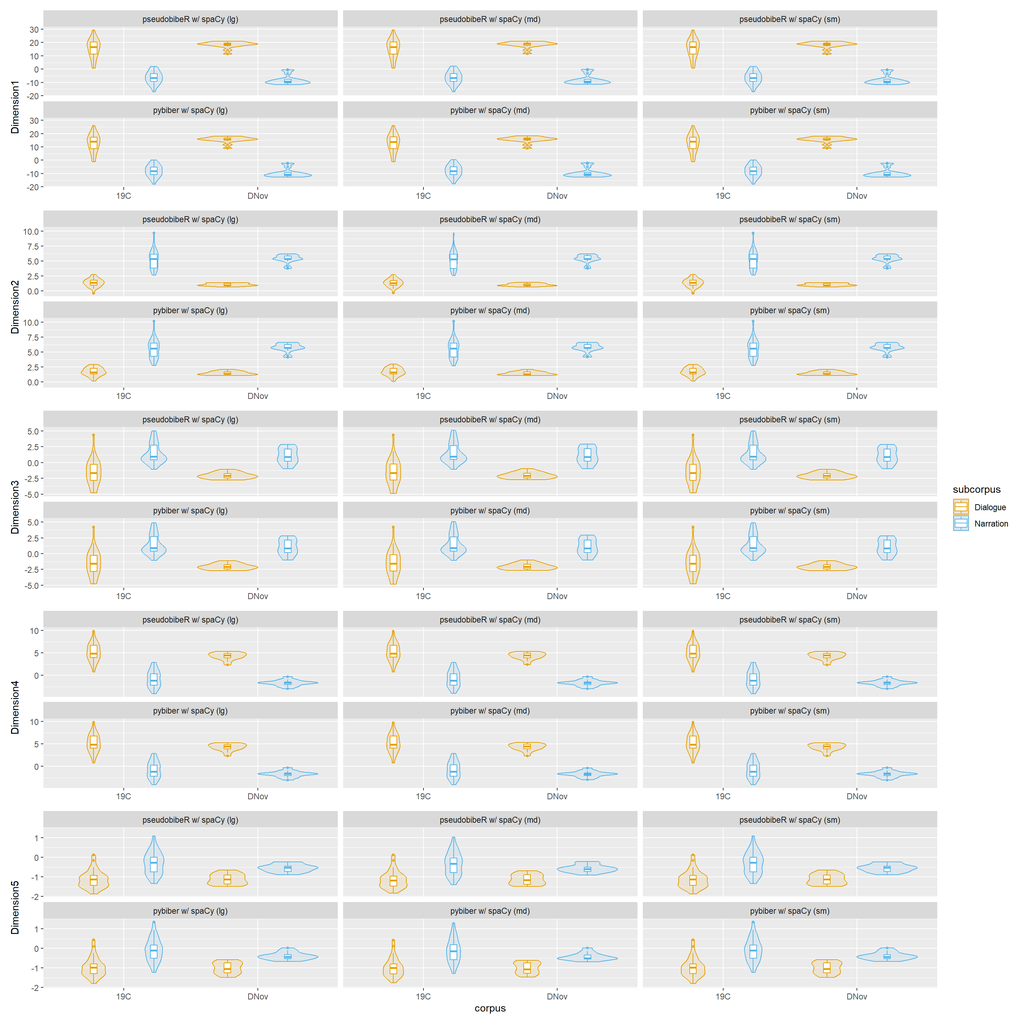

```r
d1 <- pb |>
  ggplot(aes(x = corpus, y = Dimension1, colour = subcorpus)) +
  geom_violin(position = position_dodge(0.9), aes(fill = after_scale(ggplot2::alpha(colour, 0.1)))) +
  geom_boxplot(position = position_dodge(0.9), width = 0.1, outlier.alpha = .7, outlier.size = 1) +
  facet_wrap(vars(method)) +
  scale_colour_paletteer_d("colorblindr::OkabeIto")

d2 <- pb |>
  ggplot(aes(x = corpus, y = Dimension2, colour = subcorpus)) +
  geom_violin(position = position_dodge(0.9), aes(fill = after_scale(ggplot2::alpha(colour, 0.1)))) +
  geom_boxplot(position = position_dodge(0.9), width = 0.1, outlier.alpha = .7, outlier.size = 1) +
  facet_wrap(vars(method)) +
  scale_colour_paletteer_d("colorblindr::OkabeIto")

d3 <- pb |>
  ggplot(aes(x = corpus, y = Dimension3, colour = subcorpus)) +
  geom_violin(position = position_dodge(0.9), aes(fill = after_scale(ggplot2::alpha(colour, 0.1)))) +
  geom_boxplot(position = position_dodge(0.9), width = 0.1, outlier.alpha = .7, outlier.size = 1) +
  facet_wrap(vars(method)) +
  scale_colour_paletteer_d("colorblindr::OkabeIto")

d4 <- pb |>
  ggplot(aes(x = corpus, y = Dimension4, colour = subcorpus)) +
  geom_violin(position = position_dodge(0.9), aes(fill = after_scale(ggplot2::alpha(colour, 0.1)))) +
  geom_boxplot(position = position_dodge(0.9), width = 0.1, outlier.alpha = .7, outlier.size = 1) +
  facet_wrap(vars(method)) +
  scale_colour_paletteer_d("colorblindr::OkabeIto")

d5 <- pb |>
  ggplot(aes(x = corpus, y = Dimension5, colour = subcorpus)) +
  geom_violin(position = position_dodge(0.9), aes(fill = after_scale(ggplot2::alpha(colour, 0.1)))) +
  geom_boxplot(position = position_dodge(0.9), width = 0.1, outlier.alpha = .7, outlier.size = 1) +
  facet_wrap(vars(method)) +
  scale_colour_paletteer_d("colorblindr::OkabeIto")

d1 + d2 + d3 + d4 + d5 +
  plot_layout(guides = "collect",
              axis_titles = "collect",
              ncol = 1)
```

A closer look at dimension 1, this time without Nini’s filter:

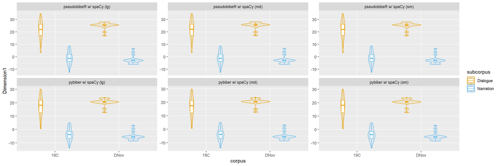

```r
pb2 <- bind_rows(
  list(
    pseudobiber_spacy_sm_total_all |>
      mutate(method = "pseudobibeR w/ spaCy (sm)", .before = doc_id),
    pseudobiber_spacy_md_total_all |>
      mutate(method = "pseudobibeR w/ spaCy (md)", .before = doc_id),
    pseudobiber_spacy_sm_total_all |>
      mutate(method = "pseudobibeR w/ spaCy (lg)", .before = doc_id),
    pybiber_spacy_sm_total_all |>
      mutate(method = "pybiber w/ spaCy (sm)", .before = doc_id),
    pybiber_spacy_md_total_all |>
      mutate(method = "pybiber w/ spaCy (md)", .before = doc_id),
    pybiber_spacy_sm_total_all |>
      mutate(method = "pybiber w/ spaCy (lg)", .before = doc_id)
  )
) |>
  mutate(subcorpus = factor(subcorpus,
                            levels = c("quotes", "nonquotes"),
                            labels = c("Dialogue", "Narration")))

pb2 |>
  ggplot(aes(x = corpus, y = Dimension1, colour = subcorpus)) +
  geom_violin(position = position_dodge(0.9), aes(fill = after_scale(ggplot2::alpha(colour, 0.1)))) +
  geom_boxplot(position = position_dodge(0.9), width = 0.1, outlier.alpha = .7, outlier.size = 1) +
  facet_wrap(vars(method), scales = "free_y") +
  scale_colour_paletteer_d("colorblindr::OkabeIto")
```

### Window sizes in BiberPlus

How much does window size influence the results when using BiberPlus?

```r
bp <- bind_rows(
  list(
    biberplus_total_all |>
      mutate(method = "BiberPlus (1,000 tokens)", .before = doc_id),
    biberplus_10k_total_all |>
      mutate(method = "BiberPlus (10,000 tokens)", .before = doc_id)
  )
) |>
  mutate(subcorpus = factor(subcorpus,
                            levels = c("quotes", "nonquotes"),
                            labels = c("Dialogue", "Narration")))
```

```r
bp |>
  group_by(corpus, subcorpus, method) |>
  skim() |>
  select(-n_missing, -complete_rate)
```

Data summary

| Name | group_by(bp, corpus, subc… |
| --- | --- |
| Number of rows | 176 |
| Number of columns | 9 |
| _______________________ |  |
| Column type frequency: |  |
| character | 1 |
| numeric | 5 |
| ________________________ |  |
| Group variables | corpus, subcorpus, method |

**Variable type: character**

| skim_variable | corpus | subcorpus | method | min | max | empty | n_unique | whitespace |
| --- | --- | --- | --- | --- | --- | --- | --- | --- |
| doc_id | 19C | Dialogue | BiberPlus (1,000 tokens) | 2 | 10 | 0 | 29 | 0 |
| doc_id | 19C | Dialogue | BiberPlus (10,000 tokens) | 2 | 10 | 0 | 29 | 0 |
| doc_id | 19C | Narration | BiberPlus (1,000 tokens) | 2 | 10 | 0 | 29 | 0 |
| doc_id | 19C | Narration | BiberPlus (10,000 tokens) | 2 | 10 | 0 | 29 | 0 |
| doc_id | DNov | Dialogue | BiberPlus (1,000 tokens) | 2 | 3 | 0 | 15 | 0 |
| doc_id | DNov | Dialogue | BiberPlus (10,000 tokens) | 2 | 3 | 0 | 15 | 0 |
| doc_id | DNov | Narration | BiberPlus (1,000 tokens) | 2 | 3 | 0 | 15 | 0 |
| doc_id | DNov | Narration | BiberPlus (10,000 tokens) | 2 | 3 | 0 | 15 | 0 |

**Variable type: numeric**

| skim_variable | corpus | subcorpus | method | mean | sd | p0 | p25 | p50 | p75 | p100 | hist |
| --- | --- | --- | --- | --- | --- | --- | --- | --- | --- | --- | --- |
| Dimension1 | 19C | Dialogue | BiberPlus (1,000 tokens) | 21.06 | 6.24 | 5.72 | 17.75 | 21.93 | 25.47 | 31.04 | ▂▂▆▇▅ |
| Dimension1 | 19C | Dialogue | BiberPlus (10,000 tokens) | 19.20 | 6.22 | 3.77 | 16.29 | 18.22 | 23.19 | 29.64 | ▂▂▇▆▆ |
| Dimension1 | 19C | Narration | BiberPlus (1,000 tokens) | 2.79 | 4.68 | -9.17 | 0.03 | 2.48 | 5.41 | 11.98 | ▁▂▇▃▃ |
| Dimension1 | 19C | Narration | BiberPlus (10,000 tokens) | 2.21 | 4.32 | -9.41 | -0.32 | 2.24 | 5.26 | 10.49 | ▁▃▇▆▃ |
| Dimension1 | DNov | Dialogue | BiberPlus (1,000 tokens) | 24.73 | 2.30 | 18.28 | 24.60 | 25.51 | 25.99 | 26.79 | ▁▁▁▂▇ |
| Dimension1 | DNov | Dialogue | BiberPlus (10,000 tokens) | 23.40 | 2.27 | 16.96 | 22.84 | 23.67 | 24.65 | 26.28 | ▁▁▁▇▇ |
| Dimension1 | DNov | Narration | BiberPlus (1,000 tokens) | 3.77 | 3.53 | -0.56 | 2.58 | 3.34 | 4.09 | 13.08 | ▂▇▁▁▁ |
| Dimension1 | DNov | Narration | BiberPlus (10,000 tokens) | 3.36 | 3.49 | -1.28 | 2.31 | 2.95 | 3.83 | 12.60 | ▂▇▁▁▁ |
| Dimension2 | 19C | Dialogue | BiberPlus (1,000 tokens) | -0.12 | 0.74 | -1.44 | -0.53 | -0.22 | 0.48 | 1.41 | ▃▇▇▇▂ |
| Dimension2 | 19C | Dialogue | BiberPlus (10,000 tokens) | -0.58 | 0.70 | -1.59 | -1.10 | -0.66 | -0.05 | 1.11 | ▅▇▂▂▁ |
| Dimension2 | 19C | Narration | BiberPlus (1,000 tokens) | 4.24 | 1.57 | 1.40 | 2.77 | 4.57 | 5.33 | 8.41 | ▅▃▇▂▁ |
| Dimension2 | 19C | Narration | BiberPlus (10,000 tokens) | 3.79 | 1.76 | 0.43 | 2.45 | 4.14 | 4.87 | 8.25 | ▃▆▇▃▁ |
| Dimension2 | DNov | Dialogue | BiberPlus (1,000 tokens) | -0.19 | 0.35 | -0.69 | -0.42 | -0.25 | -0.03 | 0.54 | ▃▇▃▁▂ |
| Dimension2 | DNov | Dialogue | BiberPlus (10,000 tokens) | -0.48 | 0.42 | -1.19 | -0.71 | -0.50 | -0.27 | 0.45 | ▃▇▇▃▂ |
| Dimension2 | DNov | Narration | BiberPlus (1,000 tokens) | 5.05 | 0.85 | 3.41 | 4.66 | 5.08 | 5.40 | 6.45 | ▂▁▇▃▃ |
| Dimension2 | DNov | Narration | BiberPlus (10,000 tokens) | 4.71 | 0.95 | 2.61 | 4.26 | 4.90 | 5.20 | 6.10 | ▂▁▂▇▃ |
| Dimension3 | 19C | Dialogue | BiberPlus (1,000 tokens) | -0.30 | 2.34 | -3.88 | -1.67 | -0.74 | 0.90 | 6.45 | ▅▇▆▁▁ |
| Dimension3 | 19C | Dialogue | BiberPlus (10,000 tokens) | -0.23 | 2.16 | -3.68 | -1.56 | -0.54 | 0.91 | 5.82 | ▅▇▆▁▂ |
| Dimension3 | 19C | Narration | BiberPlus (1,000 tokens) | 3.10 | 1.96 | -0.15 | 1.83 | 2.72 | 4.41 | 6.96 | ▆▇▇▃▃ |
| Dimension3 | 19C | Narration | BiberPlus (10,000 tokens) | 3.02 | 1.87 | -0.10 | 1.82 | 2.61 | 4.15 | 6.58 | ▅▇▇▃▅ |
| Dimension3 | DNov | Dialogue | BiberPlus (1,000 tokens) | -0.60 | 0.51 | -1.71 | -0.85 | -0.58 | -0.37 | 0.48 | ▂▅▇▇▂ |
| Dimension3 | DNov | Dialogue | BiberPlus (10,000 tokens) | -0.53 | 0.47 | -1.52 | -0.75 | -0.53 | -0.31 | 0.47 | ▂▆▇▆▂ |
| Dimension3 | DNov | Narration | BiberPlus (1,000 tokens) | 2.60 | 0.98 | 0.87 | 2.03 | 2.72 | 3.40 | 4.04 | ▆▃▆▆▇ |
| Dimension3 | DNov | Narration | BiberPlus (10,000 tokens) | 2.56 | 0.94 | 0.87 | 2.01 | 2.72 | 3.30 | 3.96 | ▆▃▆▇▆ |
| Dimension4 | 19C | Dialogue | BiberPlus (1,000 tokens) | 6.81 | 2.83 | 0.89 | 5.05 | 6.59 | 8.91 | 14.20 | ▂▇▆▆▁ |
| Dimension4 | 19C | Dialogue | BiberPlus (10,000 tokens) | 5.85 | 2.80 | 0.65 | 3.86 | 5.72 | 8.26 | 13.23 | ▃▇▆▆▁ |
| Dimension4 | 19C | Narration | BiberPlus (1,000 tokens) | -0.13 | 2.09 | -3.89 | -1.77 | -0.53 | 1.12 | 3.65 | ▃▇▃▇▅ |
| Dimension4 | 19C | Narration | BiberPlus (10,000 tokens) | -0.50 | 1.96 | -3.98 | -1.92 | -0.53 | 0.87 | 3.44 | ▅▇▂▇▂ |
| Dimension4 | DNov | Dialogue | BiberPlus (1,000 tokens) | 5.73 | 1.03 | 3.18 | 5.32 | 6.04 | 6.55 | 6.79 | ▁▁▃▃▇ |
| Dimension4 | DNov | Dialogue | BiberPlus (10,000 tokens) | 5.10 | 0.99 | 2.45 | 4.79 | 5.07 | 5.83 | 6.26 | ▁▁▂▅▇ |
| Dimension4 | DNov | Narration | BiberPlus (1,000 tokens) | -1.68 | 0.81 | -2.98 | -2.13 | -1.68 | -1.28 | 0.01 | ▆▇▇▆▂ |
| Dimension4 | DNov | Narration | BiberPlus (10,000 tokens) | -1.89 | 0.85 | -3.43 | -2.52 | -1.90 | -1.42 | -0.42 | ▂▃▇▁▃ |
| Dimension5 | 19C | Dialogue | BiberPlus (1,000 tokens) | 10.30 | 1.86 | 7.73 | 9.19 | 9.72 | 11.27 | 14.85 | ▅▇▅▂▂ |
| Dimension5 | 19C | Dialogue | BiberPlus (10,000 tokens) | 9.34 | 1.63 | 6.78 | 7.97 | 9.13 | 10.13 | 13.34 | ▇▆▇▂▂ |
| Dimension5 | 19C | Narration | BiberPlus (1,000 tokens) | 17.36 | 1.92 | 13.26 | 16.23 | 17.42 | 18.37 | 24.14 | ▂▇▇▁▁ |
| Dimension5 | 19C | Narration | BiberPlus (10,000 tokens) | 16.47 | 2.19 | 12.86 | 14.88 | 16.28 | 17.84 | 23.59 | ▆▆▇▁▁ |
| Dimension5 | DNov | Dialogue | BiberPlus (1,000 tokens) | 9.55 | 1.02 | 7.58 | 8.75 | 9.93 | 10.24 | 10.94 | ▃▅▂▇▆ |
| Dimension5 | DNov | Dialogue | BiberPlus (10,000 tokens) | 8.96 | 1.21 | 6.51 | 7.88 | 9.48 | 9.75 | 10.75 | ▁▅▁▇▃ |
| Dimension5 | DNov | Narration | BiberPlus (1,000 tokens) | 17.77 | 1.03 | 15.77 | 17.30 | 17.85 | 18.22 | 19.60 | ▂▂▇▃▂ |
| Dimension5 | DNov | Narration | BiberPlus (10,000 tokens) | 17.13 | 1.13 | 15.11 | 16.21 | 17.43 | 17.88 | 18.99 | ▅▃▅▇▃ |

While the differences aren’t huge, they are noticeable for some dimensions.

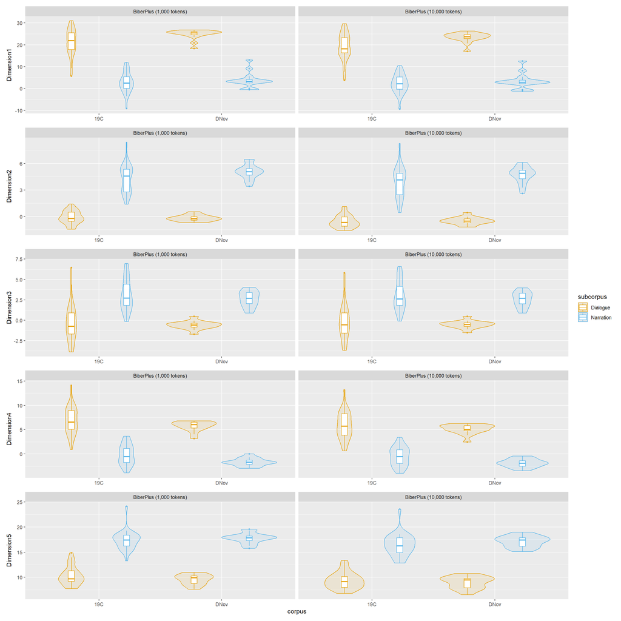

```r
d1 <- bp |>
  ggplot(aes(x = corpus, y = Dimension1, colour = subcorpus)) +
  geom_violin(position = position_dodge(0.9), aes(fill = after_scale(ggplot2::alpha(colour, 0.1)))) +
  geom_boxplot(position = position_dodge(0.9), width = 0.1, outlier.alpha = .7, outlier.size = 1) +
  facet_wrap(vars(method)) +
  scale_colour_paletteer_d("colorblindr::OkabeIto")

d2 <- bp |>
  ggplot(aes(x = corpus, y = Dimension2, colour = subcorpus)) +
  geom_violin(position = position_dodge(0.9), aes(fill = after_scale(ggplot2::alpha(colour, 0.1)))) +
  geom_boxplot(position = position_dodge(0.9), width = 0.1, outlier.alpha = .7, outlier.size = 1) +
  facet_wrap(vars(method)) +
  scale_colour_paletteer_d("colorblindr::OkabeIto")

d3 <- bp |>
  ggplot(aes(x = corpus, y = Dimension3, colour = subcorpus)) +
  geom_violin(position = position_dodge(0.9), aes(fill = after_scale(ggplot2::alpha(colour, 0.1)))) +
  geom_boxplot(position = position_dodge(0.9), width = 0.1, outlier.alpha = .7, outlier.size = 1) +
  facet_wrap(vars(method)) +
  scale_colour_paletteer_d("colorblindr::OkabeIto")

d4 <- bp |>
  ggplot(aes(x = corpus, y = Dimension4, colour = subcorpus)) +
  geom_violin(position = position_dodge(0.9), aes(fill = after_scale(ggplot2::alpha(colour, 0.1)))) +
  geom_boxplot(position = position_dodge(0.9), width = 0.1, outlier.alpha = .7, outlier.size = 1) +
  facet_wrap(vars(method)) +
  scale_colour_paletteer_d("colorblindr::OkabeIto")

d5 <- bp |>
  ggplot(aes(x = corpus, y = Dimension5, colour = subcorpus)) +
  geom_violin(position = position_dodge(0.9), aes(fill = after_scale(ggplot2::alpha(colour, 0.1)))) +
  geom_boxplot(position = position_dodge(0.9), width = 0.1, outlier.alpha = .7, outlier.size = 1) +
  facet_wrap(vars(method)) +
  scale_colour_paletteer_d("colorblindr::OkabeIto")

d1 + d2 + d3 + d4 + d5 +
  plot_layout(guides = "collect",
              axis_titles = "collect",
              ncol = 1)
```

### MAT vs. pseudobibeR (Stanza) vs. pybiber (spaCy) vs. BiberPlus vs. Biberpy

We’ll first include Nini’s filter for feature exclusion.

```r
full <- bind_rows(
  list(
    nini_total |>
      mutate(method = "MAT", .before = doc_id),
    pseudobiber_stanza_total |>
      mutate(method = "pseudobibeR\n(Stanza)", .before = doc_id),
    pseudobiber_spacy_sm_total |>
      mutate(method = "pseudobibeR\n(spaCy, sm)", .before = doc_id),
    pybiber_spacy_sm_total |>
      mutate(method = "pybiber\n(spaCy, sm)", .before = doc_id),
#    pybiber_spacy_trf_total |>
#      mutate(method = "pybiber\n(spaCy, trf)", .before = doc_id),
    biberplus_total |>
      mutate(method = "BiberPlus\n(spaCy, sm, 1k tokens)", .before = doc_id),
    biberplus_10k_total |>
      mutate(method = "BiberPlus\n(spaCy, sm, 10k tokens)", .before = doc_id),
    biberpy_total |>
      mutate(method = "Biberpy\n(spaCy, sm)", .before = doc_id)
  )
) |>
  mutate(subcorpus = factor(subcorpus,
                            levels = c("quotes", "nonquotes"),
                            labels = c("Dialogue", "Narration")),
         method = fct_inorder(method))

n_comparisons <- full$method |> levels() |> length()
```

Biberpy is the clearest outlier among the different systems.

Results from BiberPlus exhibit the second-largest differences from all others, especially on dimensions 2 and 5.

Looking at MAT, pseudobibeR and pybiber:

- Interestingly, results from Stanza and spaCy don’t seem to differ too much from each other (but slightly more than those from different spaCy models).
- MAT’s results differ a little more from the others (especially on dimension 3), but are surprisingly similar in general.

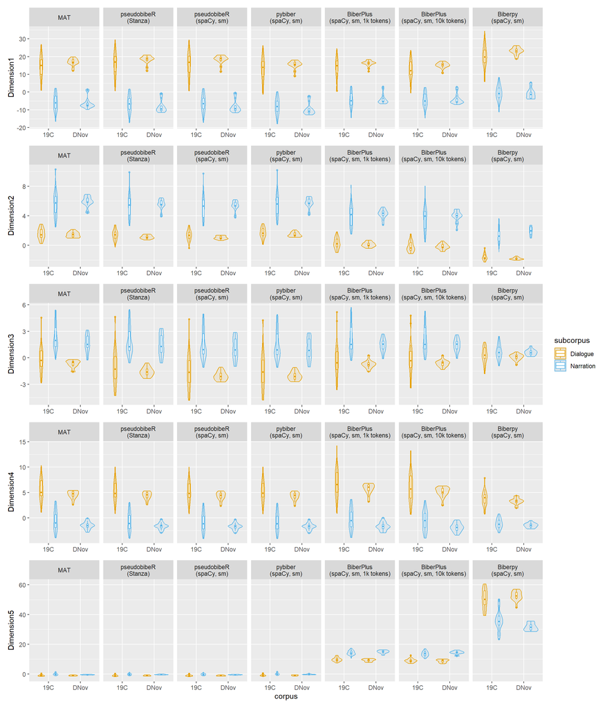

```r
d1 <- full |>
  ggplot(aes(x = corpus, y = Dimension1, colour = subcorpus)) +
  geom_violin(position = position_dodge(0.9), aes(fill = after_scale(ggplot2::alpha(colour, 0.1)))) +
  geom_boxplot(position = position_dodge(0.9), width = 0.1, outlier.alpha = .7, outlier.size = 1) +
  facet_wrap(vars(method), ncol = n_comparisons) +
  scale_colour_paletteer_d("colorblindr::OkabeIto")

d2 <- full |>
  ggplot(aes(x = corpus, y = Dimension2, colour = subcorpus)) +
  geom_violin(position = position_dodge(0.9), aes(fill = after_scale(ggplot2::alpha(colour, 0.1)))) +
  geom_boxplot(position = position_dodge(0.9), width = 0.1, outlier.alpha = .7, outlier.size = 1) +
  facet_wrap(vars(method), ncol = n_comparisons) +
  scale_colour_paletteer_d("colorblindr::OkabeIto")

d3 <- full |>
  ggplot(aes(x = corpus, y = Dimension3, colour = subcorpus)) +
  geom_violin(position = position_dodge(0.9), aes(fill = after_scale(ggplot2::alpha(colour, 0.1)))) +
  geom_boxplot(position = position_dodge(0.9), width = 0.1, outlier.alpha = .7, outlier.size = 1) +
  facet_wrap(vars(method), ncol = n_comparisons) +
  scale_colour_paletteer_d("colorblindr::OkabeIto")

d4 <- full |>
  ggplot(aes(x = corpus, y = Dimension4, colour = subcorpus)) +
  geom_violin(position = position_dodge(0.9), aes(fill = after_scale(ggplot2::alpha(colour, 0.1)))) +
  geom_boxplot(position = position_dodge(0.9), width = 0.1, outlier.alpha = .7, outlier.size = 1) +
  facet_wrap(vars(method), ncol = n_comparisons) +
  scale_colour_paletteer_d("colorblindr::OkabeIto")

d5 <- full |>
  ggplot(aes(x = corpus, y = Dimension5, colour = subcorpus)) +
  geom_violin(position = position_dodge(0.9), aes(fill = after_scale(ggplot2::alpha(colour, 0.1)))) +
  geom_boxplot(position = position_dodge(0.9), width = 0.1, outlier.alpha = .7, outlier.size = 1) +
  facet_wrap(vars(method), ncol = n_comparisons) +
  scale_colour_paletteer_d("colorblindr::OkabeIto")

d1 + d2 + d3 + d4 + d5 +
  plot_layout(guides = "collect",
              axis_titles = "collect",
              ncol = 1)
```

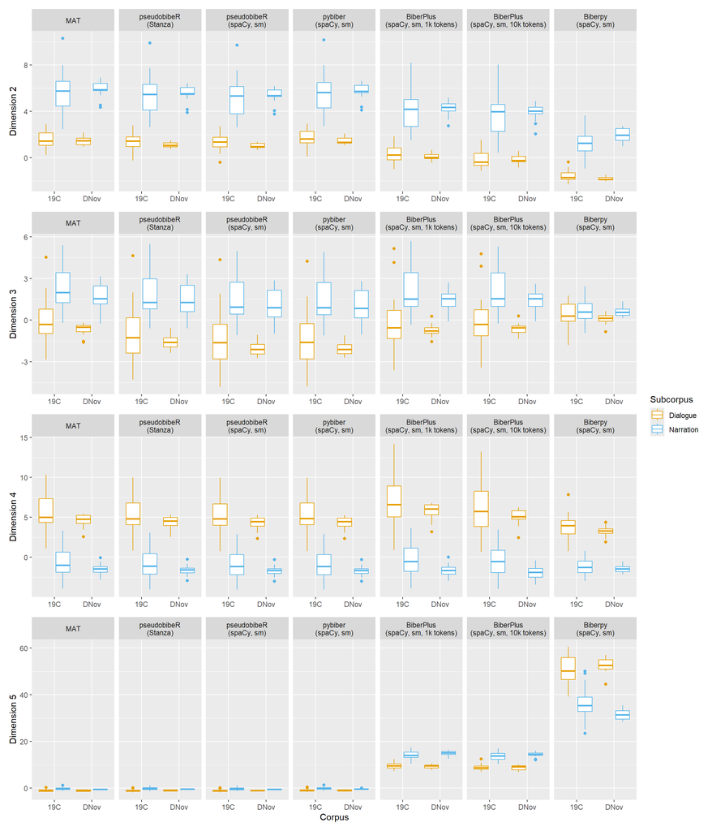

```r
# only boxplots:
d1 <- full |>
  ggplot(aes(x = corpus, y = Dimension1, colour = subcorpus)) +
  geom_boxplot(position = position_dodge(0.9)) +
  facet_wrap(vars(method), ncol = n_comparisons) +
  scale_colour_paletteer_d("colorblindr::OkabeIto") +
  labs(x = "Corpus", y = "Dimension 1", colour = "Subcorpus")

d2 <- full |>
  ggplot(aes(x = corpus, y = Dimension2, colour = subcorpus)) +
  geom_boxplot(position = position_dodge(0.9)) +
  facet_wrap(vars(method), ncol = n_comparisons) +
  scale_colour_paletteer_d("colorblindr::OkabeIto") +
  labs(x = "Corpus", y = "Dimension 2", colour = "Subcorpus")

d3 <- full |>
  ggplot(aes(x = corpus, y = Dimension3, colour = subcorpus)) +
  geom_boxplot(position = position_dodge(0.9)) +
  facet_wrap(vars(method), ncol = n_comparisons) +
  scale_colour_paletteer_d("colorblindr::OkabeIto") +
  labs(x = "Corpus", y = "Dimension 3", colour = "Subcorpus")

d4 <- full |>
  ggplot(aes(x = corpus, y = Dimension4, colour = subcorpus)) +
  geom_boxplot(position = position_dodge(0.9)) +
  facet_wrap(vars(method), ncol = n_comparisons) +
  scale_colour_paletteer_d("colorblindr::OkabeIto") +
  labs(x = "Corpus", y = "Dimension 4", colour = "Subcorpus")

d5 <- full |>
  ggplot(aes(x = corpus, y = Dimension5, colour = subcorpus)) +
  geom_boxplot(position = position_dodge(0.9)) +
  facet_wrap(vars(method), ncol = n_comparisons) +
  scale_colour_paletteer_d("colorblindr::OkabeIto") +
  labs(x = "Corpus", y = "Dimension 5", colour = "Subcorpus")

# 11.5x11
d2 + d3 + d4 + d5 +
  plot_layout(guides = "collect",
              axis_titles = "collect",
              ncol = 1)
```

If we compare these results to those from Egbert and Mahlberg (2020) – where only dimension 1 is available – we see more pronounced differences. However, these are likely mostly due to the exclusion of several features in our analysis.

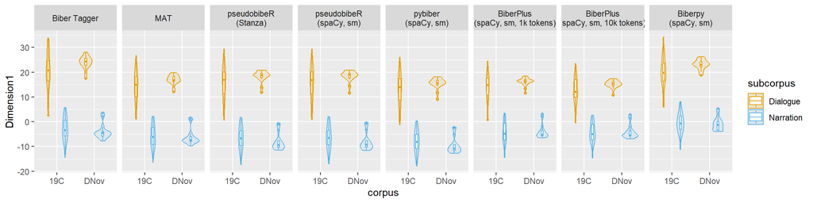

```r
biber_comparison_filtered <- full_scores_egbert_mahlberg |>
  select(doc_id:subcorpus, Biber_D1) |>
  mutate(method = "Biber Tagger", .before = doc_id,
         subcorpus = factor(subcorpus)) |>
  rename(Dimension1 = Biber_D1) |>
  bind_rows(full |> select(method:Dimension1)) |>
  mutate(method = fct_inorder(method))

biber_comparison_filtered |>
  ggplot(aes(x = corpus, y = Dimension1, colour = subcorpus)) +
  geom_violin(position = position_dodge(0.9), aes(fill = after_scale(ggplot2::alpha(colour, 0.1)))) +
  geom_boxplot(position = position_dodge(0.9), width = 0.1, outlier.alpha = .7, outlier.size = 1) +
  facet_wrap(vars(method), ncol = n_comparisons + 1) +
  scale_colour_paletteer_d("colorblindr::OkabeIto")
```

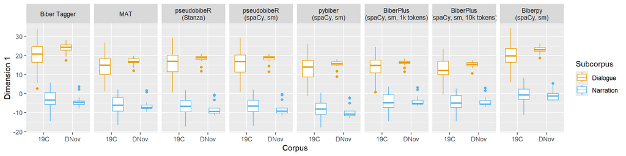

```r
# only boxplots for paper (13x5):
biber_comparison_filtered |>
  ggplot(aes(x = corpus, y = Dimension1, colour = subcorpus)) +
  geom_boxplot(position = position_dodge(0.9)) +
  facet_wrap(vars(method), ncol = n_comparisons + 1) +
  scale_colour_paletteer_d("colorblindr::OkabeIto") +
  labs(x = "Corpus", y = "Dimension 1", colour = "Subcorpus")
```

If we compare our dimensions using all features associated with them according to Biber (1988), we get results that are more dissimilar.

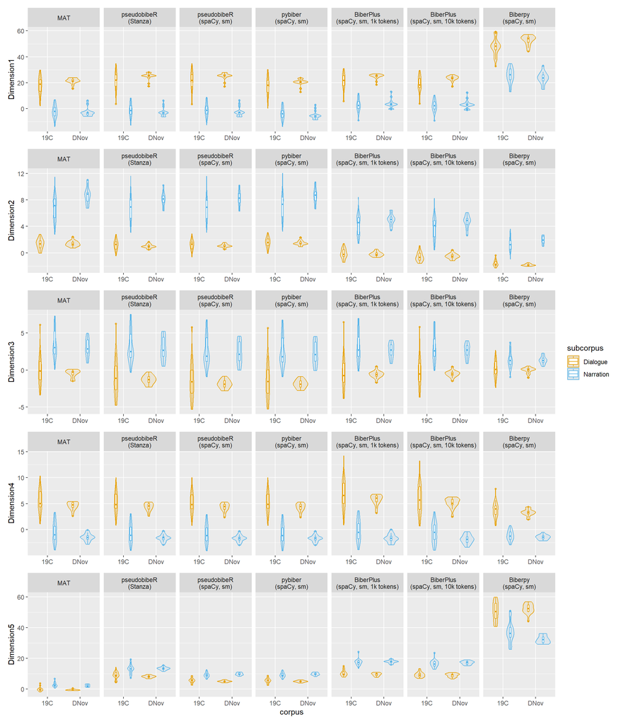

```r
full_all <- bind_rows(
  list(
    nini_total_all |>
      mutate(method = "MAT", .before = doc_id),
    pseudobiber_stanza_total_all |>
      mutate(method = "pseudobibeR\n(Stanza)", .before = doc_id),
    pseudobiber_spacy_sm_total_all |>
      mutate(method = "pseudobibeR\n(spaCy, sm)", .before = doc_id),
    pybiber_spacy_sm_total_all |>
      mutate(method = "pybiber\n(spaCy, sm)", .before = doc_id),
    biberplus_total_all |>
      mutate(method = "BiberPlus\n(spaCy, sm, 1k tokens)", .before = doc_id),
    biberplus_10k_total_all |>
      mutate(method = "BiberPlus\n(spaCy, sm, 10k tokens)", .before = doc_id),
    biberpy_total_all |>
      mutate(method = "Biberpy\n(spaCy, sm)", .before = doc_id)
  )
) |>
  mutate(subcorpus = factor(subcorpus,
                            levels = c("quotes", "nonquotes"),
                            labels = c("Dialogue", "Narration")),
         method = fct_inorder(method))

n_comparisons_all <- full_all$method |> levels() |> length()

d1 <- full_all |>
  ggplot(aes(x = corpus, y = Dimension1, colour = subcorpus)) +
  geom_violin(position = position_dodge(0.9), aes(fill = after_scale(ggplot2::alpha(colour, 0.1)))) +
  geom_boxplot(position = position_dodge(0.9), width = 0.1, outlier.alpha = .7, outlier.size = 1) +
  facet_wrap(vars(method), ncol = n_comparisons_all) +
  scale_colour_paletteer_d("colorblindr::OkabeIto")

d2 <- full_all |>
  ggplot(aes(x = corpus, y = Dimension2, colour = subcorpus)) +
  geom_violin(position = position_dodge(0.9), aes(fill = after_scale(ggplot2::alpha(colour, 0.1)))) +
  geom_boxplot(position = position_dodge(0.9), width = 0.1, outlier.alpha = .7, outlier.size = 1) +
  facet_wrap(vars(method), ncol = n_comparisons_all) +
  scale_colour_paletteer_d("colorblindr::OkabeIto")

d3 <- full_all |>
  ggplot(aes(x = corpus, y = Dimension3, colour = subcorpus)) +
  geom_violin(position = position_dodge(0.9), aes(fill = after_scale(ggplot2::alpha(colour, 0.1)))) +
  geom_boxplot(position = position_dodge(0.9), width = 0.1, outlier.alpha = .7, outlier.size = 1) +
  facet_wrap(vars(method), ncol = n_comparisons_all) +
  scale_colour_paletteer_d("colorblindr::OkabeIto")

d4 <- full_all |>
  ggplot(aes(x = corpus, y = Dimension4, colour = subcorpus)) +
  geom_violin(position = position_dodge(0.9), aes(fill = after_scale(ggplot2::alpha(colour, 0.1)))) +
  geom_boxplot(position = position_dodge(0.9), width = 0.1, outlier.alpha = .7, outlier.size = 1) +
  facet_wrap(vars(method), ncol = n_comparisons_all) +
  scale_colour_paletteer_d("colorblindr::OkabeIto")

d5 <- full_all |>
  ggplot(aes(x = corpus, y = Dimension5, colour = subcorpus)) +
  geom_violin(position = position_dodge(0.9), aes(fill = after_scale(ggplot2::alpha(colour, 0.1)))) +
  geom_boxplot(position = position_dodge(0.9), width = 0.1, outlier.alpha = .7, outlier.size = 1) +
  facet_wrap(vars(method), ncol = n_comparisons_all) +
  scale_colour_paletteer_d("colorblindr::OkabeIto")

d1 + d2 + d3 + d4 + d5 +
  plot_layout(guides = "collect",
              axis_titles = "collect",
              ncol = 1)
```

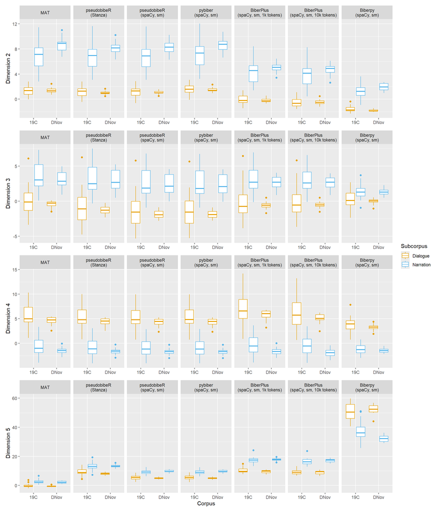

```r
# only boxplots:
d1 <- full_all |>
  ggplot(aes(x = corpus, y = Dimension1, colour = subcorpus)) +
  geom_boxplot(position = position_dodge(0.9)) +
  facet_wrap(vars(method), ncol = n_comparisons_all) +
  scale_colour_paletteer_d("colorblindr::OkabeIto") +
  labs(x = "Corpus", y = "Dimension 1", colour = "Subcorpus")

d2 <- full_all |>
  ggplot(aes(x = corpus, y = Dimension2, colour = subcorpus)) +
  geom_boxplot(position = position_dodge(0.9)) +
  facet_wrap(vars(method), ncol = n_comparisons_all) +
  scale_colour_paletteer_d("colorblindr::OkabeIto") +
  labs(x = "Corpus", y = "Dimension 2", colour = "Subcorpus")

d3 <- full_all |>
  ggplot(aes(x = corpus, y = Dimension3, colour = subcorpus)) +
  geom_boxplot(position = position_dodge(0.9)) +
  facet_wrap(vars(method), ncol = n_comparisons_all) +
  scale_colour_paletteer_d("colorblindr::OkabeIto") +
  labs(x = "Corpus", y = "Dimension 3", colour = "Subcorpus")

d4 <- full_all |>
  ggplot(aes(x = corpus, y = Dimension4, colour = subcorpus)) +
  geom_boxplot(position = position_dodge(0.9)) +
  facet_wrap(vars(method), ncol = n_comparisons_all) +
  scale_colour_paletteer_d("colorblindr::OkabeIto") +
  labs(x = "Corpus", y = "Dimension 4", colour = "Subcorpus")

d5 <- full_all |>
  ggplot(aes(x = corpus, y = Dimension5, colour = subcorpus)) +
  geom_boxplot(position = position_dodge(0.9)) +
  facet_wrap(vars(method), ncol = n_comparisons_all) +
  scale_colour_paletteer_d("colorblindr::OkabeIto") +
  labs(x = "Corpus", y = "Dimension 5", colour = "Subcorpus")

# 11.5x11
d2 + d3 + d4 + d5 +
  plot_layout(guides = "collect",
              axis_titles = "collect",
              ncol = 1)
```

### Biber Tagger

These are, however, much closer to the results from the Biber Tagger:

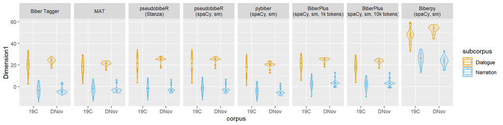

```r
biber_comparison <- full_scores_egbert_mahlberg |>
  select(doc_id:subcorpus, Biber_D1) |>
  mutate(method = "Biber Tagger", .before = doc_id,
         subcorpus = factor(subcorpus)) |>
  rename(Dimension1 = Biber_D1) |>
  bind_rows(full_all |> select(method:Dimension1)) |>
  mutate(method = fct_inorder(method))

biber_comparison |>
  ggplot(aes(x = corpus, y = Dimension1, colour = subcorpus)) +
  geom_violin(position = position_dodge(0.9), aes(fill = after_scale(ggplot2::alpha(colour, 0.1)))) +
  geom_boxplot(position = position_dodge(0.9), width = 0.1, outlier.alpha = .7, outlier.size = 1) +
  facet_wrap(vars(method), ncol = n_comparisons_all + 1) +
  scale_colour_paletteer_d("colorblindr::OkabeIto")
```

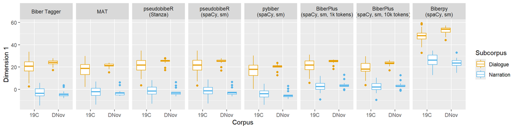

```r
# paper (13x5)
d1_bc <- biber_comparison |>
  ggplot(aes(x = corpus, y = Dimension1, colour = subcorpus)) +
  geom_boxplot(position = position_dodge(0.9)) +
  facet_wrap(vars(method), ncol = n_comparisons_all + 1) +
  scale_colour_paletteer_d("colorblindr::OkabeIto") +
  labs(x = "Corpus", y = "Dimension 1", colour = "Subcorpus")

d1_bc
```

```r
full_all <- bind_rows(
  list(
    nini_total_all |>
      mutate(method = "MAT", .before = doc_id),
    pseudobiber_stanza_total_all |>
      mutate(method = "pseudobibeR (Stanza)", .before = doc_id),
    pseudobiber_spacy_sm_total_all |>
      mutate(method = "pseudobibeR (spaCy, sm)", .before = doc_id),
    pseudobiber_spacy_lg_total_all |>
      mutate(method = "pseudobibeR (spaCy, lg)", .before = doc_id),
    pybiber_spacy_sm_total_all |>
      mutate(method = "pybiber (spaCy, sm)", .before = doc_id),
    pybiber_spacy_trf_total_all |>
      mutate(method = "pybiber (spaCy, trf)", .before = doc_id),
    biberplus_total_all |>
      mutate(method = "BiberPlus (spaCy, sm, 1k tokens)", .before = doc_id),
    biberplus_10k_total_all |>
      mutate(method = "BiberPlus (spaCy, sm, 10k tokens)", .before = doc_id),
    biberpy_total_all |>
      mutate(method = "Biberpy (spaCy, sm)", .before = doc_id)
  )
) |>
  mutate(
    subcorpus = factor(subcorpus,
                            levels = c("quotes", "nonquotes"),
                            labels = c("Dialogue", "Narration"))
    )

biber_comparison <- full_scores_egbert_mahlberg |>
  select(doc_id:subcorpus, Biber_D1) |>
  mutate(method = "Biber Tagger", .before = doc_id,
         subcorpus = factor(subcorpus)) |>
  rename(Dimension1 = Biber_D1) |>
  bind_rows(full_all |> select(method:Dimension1)) |>
  mutate(method = fct_inorder(method),
         segment_id = str_c(doc_id, "_", subcorpus))
```

To compare these systems in a linear mixed-effects model, we’ll take dimension 1 scores as the dependent variable. Independent variables will be `corpus`, `subcorpus` and `method` (e.g. “pseudobibeR (Stanza)”). We’ll also account for interactions between corpus and subcorpus as well as method and subcorpus. Since each of the 44 novels has been split into two segments (dialogue and narration) and there are multiple Dimension 1 scores for each segment (by different methods), observations are not independent and we need two random effects: novel (`doc_id`) and document/segment (`segment_id`).[^1]

Due to the number of predictors in the model, results are a little hard to grasp at first glance:

- `corpus`: All other things being equal (ceteris paribus -> c.p.), meaning all other predictors at their reference levels, Dickens’ novels have slightly higher (3.63) dimension 1 scores than other 19th century novels (but wait for the interaction effect with `subcorpus`).
- `subcorpus`: C.p., dimension 1 scores for narration are *much* lower (23.42 points) than for dialogue, as expected.
- interaction of `corpus` and `subcorpus`: There is a significant negative interaction here. From the effects of `corpus` and `subcorpus` alone, you’d expect Dickens’ scores to be higher in both subcorpora, but for narration, they’re actually slightly lower than those of other 19th century novels (+3.63 - 4.41 = -0.78). (C.p., so across methods.)
- `method` and its interaction with `subcorpus`: All systems differ from the Biber Tagger, but to different extent. Biberpy is clearly the outlier here. BiberPlus stays close to the Biber Tagger for dialogue, but it is quite far away from it for narration (interaction effects of around 6 points). pseudobibeR stays relatively close to the Biber Tagger regardless of subcorpus. For pybiber and MAT, this is true for narration but less so for dialogue.

The means and standard deviations for the Biber Tagger results may also help to better understand the model’s coefficients:

```r
biber_comparison |>
  filter(method == "Biber Tagger") |>
  group_by(corpus, subcorpus) |>
  summarise(mean = mean(Dimension1),
            median = median(Dimension1),
            sd = sd(Dimension1))
```

[output not shown]

| corpus | subcorpus | mean | median | sd |
| --- | --- | --- | --- | --- |
| 19C | Dialogue | 20.418621 | 20.83 | 7.740514 |
| 19C | Narration | -3.004138 | -3.38 | 4.860313 |
| DNov | Dialogue | 23.834000 | 24.37 | 2.725304 |
| DNov | Narration | -3.999333 | -4.60 | 3.140144 |

```r
mixed_mod <- lmer(Dimension1 ~ corpus + subcorpus + corpus:subcorpus + method + method:subcorpus +
                    (1|doc_id) + (1|segment_id),
                  biber_comparison)

model_parameters(mixed_mod)
```

| Parameter | Coefficient | SE | CI | CI_low | CI_high | t | df_error | p | Effects | Group |
| --- | --- | --- | --- | --- | --- | --- | --- | --- | --- | --- |
| (Intercept) | 20.3453410 | 0.97537073 | 0.95 | 18.43093950 | 22.2597425 | 20.859085 | 855 | 1.970933e-78 | fixed |  |
| corpusDNov | 3.6303330 | 1.62638752 | 0.95 | 0.43815320 | 6.8225128 | 2.232145 | 855 | 2.586371e-02 | fixed |  |
| subcorpusNarration | -23.4241106 | 1.08449417 | 0.95 | -25.55269334 | -21.2955279 | -21.599112 | 855 | 6.565519e-83 | fixed |  |
| methodMAT | -2.6657965 | 0.33198735 | 0.95 | -3.31740213 | -2.0141908 | -8.029813 | 855 | 3.221267e-15 | fixed |  |
| methodpseudobibeR (Stanza) | 1.0855927 | 0.33198735 | 0.95 | 0.43398699 | 1.7371983 | 3.269982 | 855 | 1.118550e-03 | fixed |  |
| methodpseudobibeR (spaCy, sm) | 1.0545536 | 0.33198735 | 0.95 | 0.40294793 | 1.7061593 | 3.176487 | 855 | 1.544180e-03 | fixed |  |
| methodpseudobibeR (spaCy, lg) | 1.1772278 | 0.33198735 | 0.95 | 0.52562217 | 1.8288335 | 3.546002 | 855 | 4.123734e-04 | fixed |  |
| methodpybiber (spaCy, sm) | -3.4266497 | 0.33198735 | 0.95 | -4.07825539 | -2.7750441 | -10.321627 | 855 | 1.280360e-23 | fixed |  |
| methodpybiber (spaCy, trf) | -2.8548323 | 0.33198735 | 0.95 | -3.50643799 | -2.2032267 | -8.599220 | 855 | 3.794576e-17 | fixed |  |
| methodBiberPlus (spaCy, sm, 1k tokens) | 0.7289098 | 0.33198735 | 0.95 | 0.07730410 | 1.3805154 | 2.195595 | 855 | 2.838897e-02 | fixed |  |

[output cut: 15 more lines]

```r
model_parameters(mixed_mod, standardize = "refit")
```

| Parameter | Coefficient | SE | CI | CI_low | CI_high | t | df_error | p | Effects | Group |
| --- | --- | --- | --- | --- | --- | --- | --- | --- | --- | --- |
| (Intercept) | 0.51923861 | 0.064520909 | 0.95 | 0.392600683 | 0.64587654 | 8.047602 | 855 | 2.814628e-15 | fixed |  |
| corpusDNov | 0.24014703 | 0.107585761 | 0.95 | 0.028983895 | 0.45131017 | 2.232145 | 855 | 2.586371e-02 | fixed |  |
| subcorpusNarration | -1.54950818 | 0.071739440 | 0.95 | -1.690314220 | -1.40870213 | -21.599112 | 855 | 6.565519e-83 | fixed |  |
| methodMAT | -0.17634281 | 0.021961010 | 0.95 | -0.219446613 | -0.13323900 | -8.029813 | 855 | 3.221267e-15 | fixed |  |
| methodpseudobibeR (Stanza) | 0.07181211 | 0.021961010 | 0.95 | 0.028708300 | 0.11491591 | 3.269982 | 855 | 1.118550e-03 | fixed |  |
| methodpseudobibeR (spaCy, sm) | 0.06975887 | 0.021961010 | 0.95 | 0.026655062 | 0.11286267 | 3.176487 | 855 | 1.544180e-03 | fixed |  |
| methodpseudobibeR (spaCy, lg) | 0.07787379 | 0.021961010 | 0.95 | 0.034769980 | 0.12097759 | 3.546002 | 855 | 4.123734e-04 | fixed |  |
| methodpybiber (spaCy, sm) | -0.22667336 | 0.021961010 | 0.95 | -0.269777162 | -0.18356955 | -10.321627 | 855 | 1.280360e-23 | fixed |  |
| methodpybiber (spaCy, trf) | -0.18884756 | 0.021961010 | 0.95 | -0.231951361 | -0.14574375 | -8.599220 | 855 | 3.794576e-17 | fixed |  |
| methodBiberPlus (spaCy, sm, 1k tokens) | 0.04821748 | 0.021961010 | 0.95 | 0.005113677 | 0.09132129 | 2.195595 | 855 | 2.838897e-02 | fixed |  |

[output cut: 15 more lines]

```r
model_performance(mixed_mod)
```

| AIC | AICc | BIC | R2_conditional | R2_marginal | ICC | RMSE | Sigma |
| --- | --- | --- | --- | --- | --- | --- | --- |
| 3715.466 | 3716.989 | 3834.964 | 0.9894455 | 0.8766707 | 0.91442 | 1.461244 | 1.557159 |

Model assumptions seem to be mostly met. There appears to be a little heteroscedasticity, but as it seems to be leveraged by few outliers, it doesn’t strike us as concerning. The two very high variance inflation factors disappear entirely if we decide to leave out the method:subcorpus interaction (and high VIFs for interactions can generally be safely ignored).

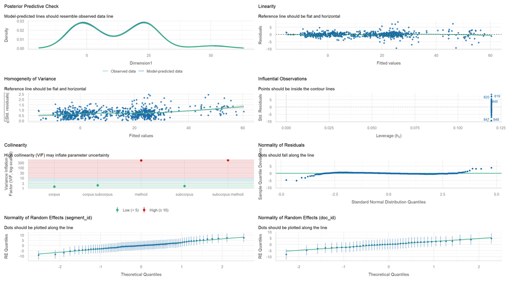

```r
check_model(mixed_mod)
```

Stargazer output for the paper:

```r
stargazer(mixed_mod, type = "text",
          ci = TRUE, digits = 2,
          star.cutoffs = c(0.05, 0.01, 0.001))
```

```
========================================================================================
                                                                Dependent variable:
                                                           -----------------------------
                                                                    Dimension1
----------------------------------------------------------------------------------------
corpusDNov                                                             3.63*
                                                                   (0.44, 6.82)

subcorpusNarration                                                   -23.42***
                                                                 (-25.55, -21.30)

methodMAT                                                            -2.67***
                                                                  (-3.32, -2.02)

methodpseudobibeR (Stanza)                                            1.09**
                                                                   (0.43, 1.74)

methodpseudobibeR (spaCy, sm)                                         1.05**
                                                                   (0.40, 1.71)

methodpseudobibeR (spaCy, lg)                                         1.18***
                                                                   (0.53, 1.83)

methodpybiber (spaCy, sm)                                            -3.43***
                                                                  (-4.08, -2.78)

methodpybiber (spaCy, trf)                                           -2.85***
                                                                  (-3.51, -2.20)

methodBiberPlus (spaCy, sm, 1k tokens)                                 0.73*
                                                                   (0.08, 1.38)

methodBiberPlus (spaCy, sm, 10k tokens)                               -0.95**
                                                                  (-1.60, -0.30)

methodBiberpy (spaCy, sm)                                            27.83***
                                                                  (27.18, 28.48)

corpusDNov:subcorpusNarration                                         -4.41*
                                                                  (-7.89, -0.92)
```

[output cut: 23 more lines]

```
                                                                   (5.98, 7.82)

subcorpusNarration:methodBiberpy (spaCy, sm)                           0.54
                                                                   (-0.38, 1.46)

Constant                                                             20.35***
                                                                  (18.43, 22.26)

----------------------------------------------------------------------------------------
Observations                                                            880
Log Likelihood                                                       -1,832.73
Akaike Inf. Crit.                                                    3,715.47
Bayesian Inf. Crit.                                                  3,834.96
========================================================================================
Note:                                                      *p<0.05; **p<0.01; ***p<0.001
```

A closer look at the dialogue/narration contrast across different systems reveals that all systems are able to reproduce the distinction, albeit to different degrees. MAT, pybiber and especially BiberPlus show smaller contrasts.

```r
contrasts <- estimate_contrasts(
    mixed_mod,
    contrast = "subcorpus",
    by = "method",
    comparison = "pairwise",
    backend = "emmeans",
    ci = 0.95,
    p_adjust = "none"
)

contrasts
```

|  | Level1 | Level2 | method | Difference | CI_low | CI_high | SE | df | t | p |
| --- | --- | --- | --- | --- | --- | --- | --- | --- | --- | --- |
| 1 | Dialogue | Narration | Biber Tagger | 25.62742 | 23.75230 | 27.50253 | 0.942839 | 83.47388 | 27.18112 | 3.147903e-43 |
| 2 | Dialogue | Narration | BiberPlus (spaCy, sm, 10k tokens) | 18.72406 | 16.84895 | 20.59917 | 0.942839 | 83.47388 | 19.85924 | 2.260450e-33 |
| 3 | Dialogue | Narration | BiberPlus (spaCy, sm, 1k tokens) | 19.88871 | 18.01360 | 21.76383 | 0.942839 | 83.47388 | 21.09450 | 3.357231e-35 |
| 4 | Dialogue | Narration | Biberpy (spaCy, sm) | 25.08546 | 23.21035 | 26.96057 | 0.942839 | 83.47388 | 26.60631 | 1.561821e-42 |
| 5 | Dialogue | Narration | MAT | 22.11649 | 20.24138 | 23.99160 | 0.942839 | 83.47388 | 23.45734 | 1.685658e-38 |
| 6 | Dialogue | Narration | pseudobibeR (spaCy, lg) | 24.89861 | 23.02350 | 26.77372 | 0.942839 | 83.47388 | 26.40813 | 2.730376e-42 |
| 7 | Dialogue | Narration | pseudobibeR (spaCy, sm) | 24.80376 | 22.92865 | 26.67887 | 0.942839 | 83.47388 | 26.30753 | 3.630099e-42 |
| 8 | Dialogue | Narration | pseudobibeR (Stanza) | 24.99196 | 23.11685 | 26.86707 | 0.942839 | 83.47388 | 26.50714 | 2.064661e-42 |
| 9 | Dialogue | Narration | pybiber (spaCy, sm) | 23.05375 | 21.17863 | 24.92886 | 0.942839 | 83.47388 | 24.45141 | 8.148790e-40 |
| 10 | Dialogue | Narration | pybiber (spaCy, trf) | 23.51696 | 21.64184 | 25.39207 | 0.942839 | 83.47388 | 24.94271 | 1.886801e-40 |

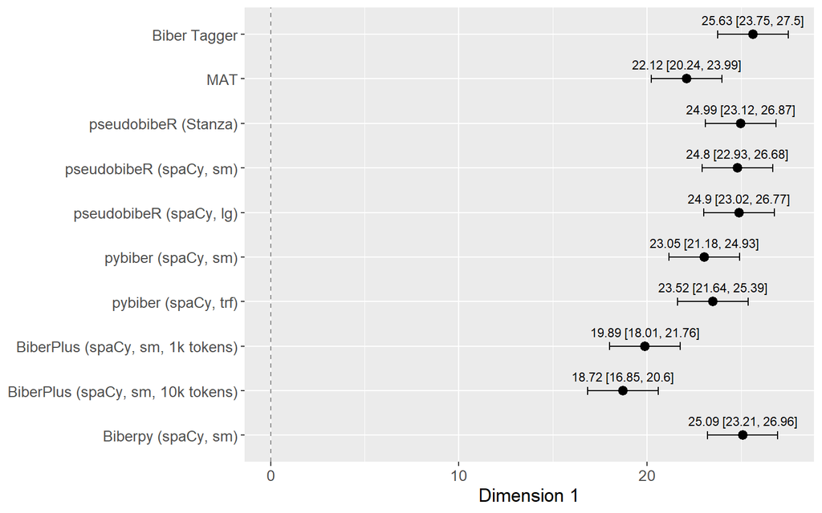

```r
contrasts |>
  as_tibble() |>
  mutate(method = fct_rev(method)) |>
  ggplot(aes(x = Difference, y = method)) +
  geom_vline(
    xintercept = 0,
    linetype = "dashed",
    colour = "grey55"
  ) +
  geom_errorbar(aes(xmin = CI_low, xmax = CI_high),
                width = 0.18,
                orientation = "y") +
  geom_point(size = 2.8) +
  labs(x = "Dimension 1", y = NULL) +
  geom_text(aes(label = str_c(round(Difference, 2), " [", round(CI_low, 2), ", ", round(CI_high, 2), "]")), size = 3, vjust = -1) +
  theme(text = element_text(size = 13))
```

MAT’s, Biberplus’ and pybiber’s contrasts are indeed significantly different from those of the Biber Tagger:

```r
emm <- emmeans(mixed_mod, ~ subcorpus | method)

dn_contrasts <- contrast(
    emm,
    method = list("Dialogue - Narration" = c(1, -1))
)

system_vs_biber <- contrast(
    dn_contrasts,
    method = "trt.vs.ctrl",
    ref = 1,
    by = NULL,
    adjust = "dunnett"
)

summary(system_vs_biber, infer = c(TRUE, TRUE))
```

|  | contrast | estimate | SE | df | lower.CL | upper.CL | t.ratio | p.value |
| --- | --- | --- | --- | --- | --- | --- | --- | --- |
| 1 | (Dialogue - Narration MAT) - (Dialogue - Narration Biber Tagger) | -3.5109242 | 0.469501 | 774 | -4.783807 | -2.2380416 | -7.477991 | 2.048361e-13 |
| 2 | (Dialogue - Narration pseudobibeR (Stanza)) - (Dialogue - Narration Biber Tagger) | -0.6354548 | 0.469501 | 774 | -1.908337 | 0.6374279 | -1.353468 | 6.528908e-01 |
| 3 | (Dialogue - Narration pseudobibeR (spaCy, sm)) - (Dialogue - Narration Biber Tagger) | -0.8236515 | 0.469501 | 774 | -2.096534 | 0.4492311 | -1.754313 | 3.947069e-01 |
| 4 | (Dialogue - Narration pseudobibeR (spaCy, lg)) - (Dialogue - Narration Biber Tagger) | -0.7288018 | 0.469501 | 774 | -2.001684 | 0.5440808 | -1.552290 | 5.231131e-01 |
| 5 | (Dialogue - Narration pybiber (spaCy, sm)) - (Dialogue - Narration Biber Tagger) | -2.5736692 | 0.469501 | 774 | -3.846552 | -1.3007865 | -5.481712 | 5.054769e-07 |
| 6 | (Dialogue - Narration pybiber (spaCy, trf)) - (Dialogue - Narration Biber Tagger) | -2.1104589 | 0.469501 | 774 | -3.383341 | -0.8375762 | -4.495110 | 7.079778e-05 |
| 7 | (Dialogue - Narration BiberPlus (spaCy, sm, 1k tokens)) - (Dialogue - Narration Biber Tagger) | -5.7387003 | 0.469501 | 774 | -7.011583 | -4.4658177 | -12.222977 | 0.000000e+00 |
| 8 | (Dialogue - Narration BiberPlus (spaCy, sm, 10k tokens)) - (Dialogue - Narration Biber Tagger) | -6.9033532 | 0.469501 | 774 | -8.176236 | -5.6304706 | -14.703596 | 0.000000e+00 |
| 9 | (Dialogue - Narration Biberpy (spaCy, sm)) - (Dialogue - Narration Biber Tagger) | -0.5419522 | 0.469501 | 774 | -1.814835 | 0.7309305 | -1.154315 | 7.725774e-01 |

As requested by a reviewer, here are scatter plots to show the dimension 1 scores of individual documents – always comparing the Biber Tagger against one other system. The dashed line represents perfect correlation. Points under the line mean lower dimension 1 scores for the system in question than for the Biber Tagger, points over the line mean higher scores.

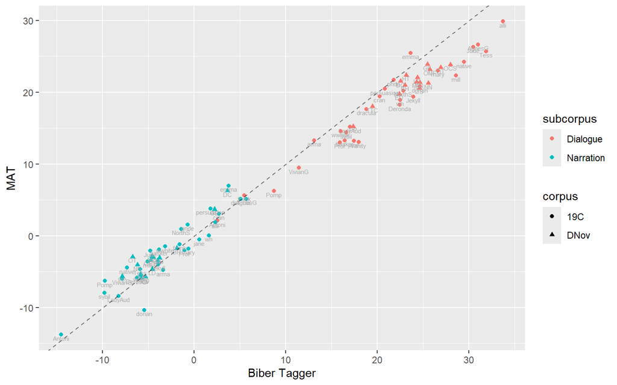

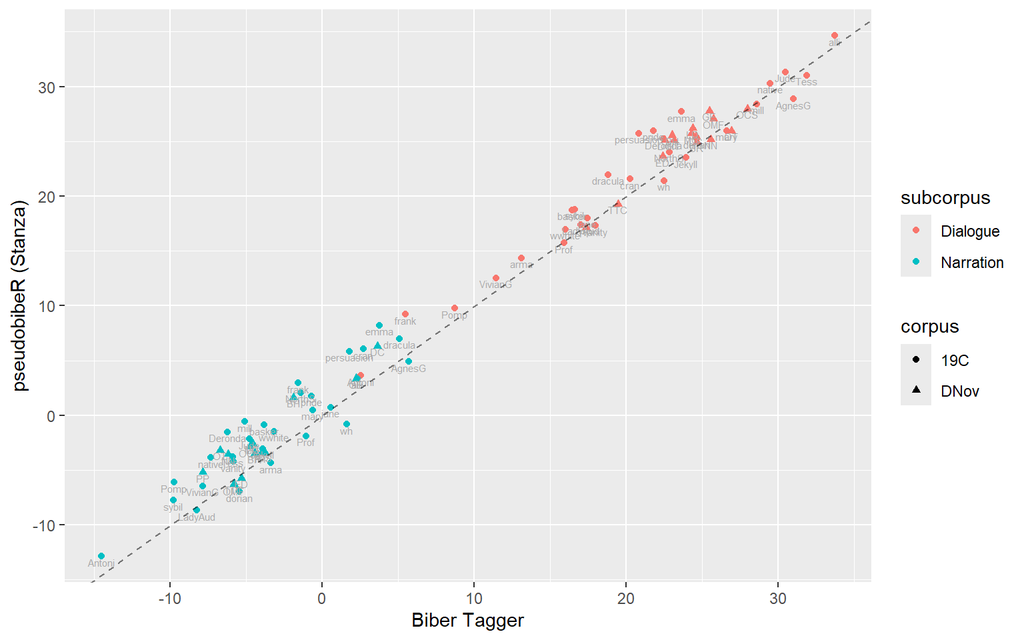

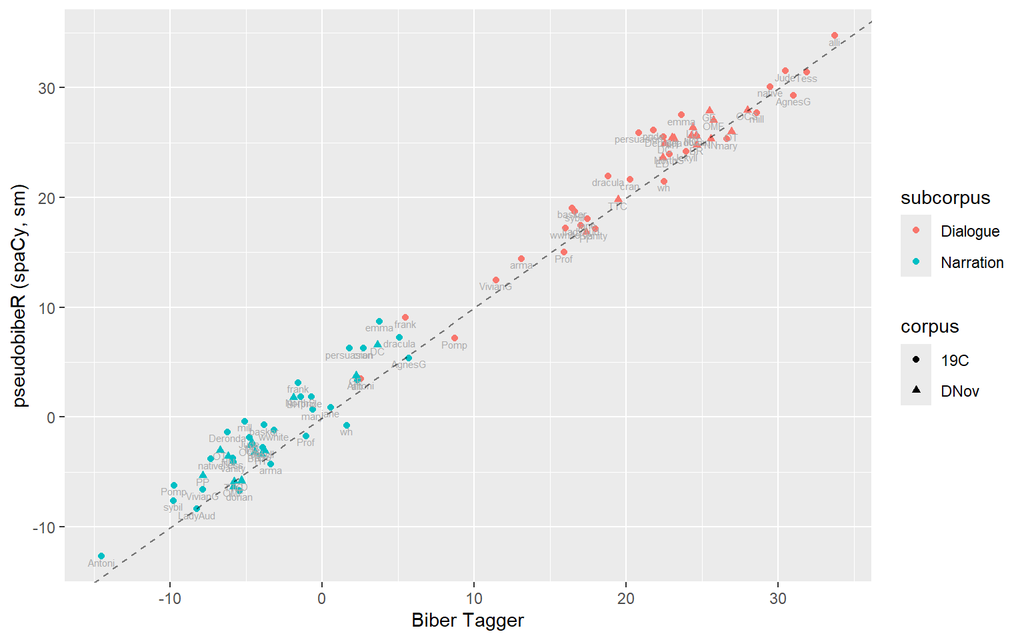

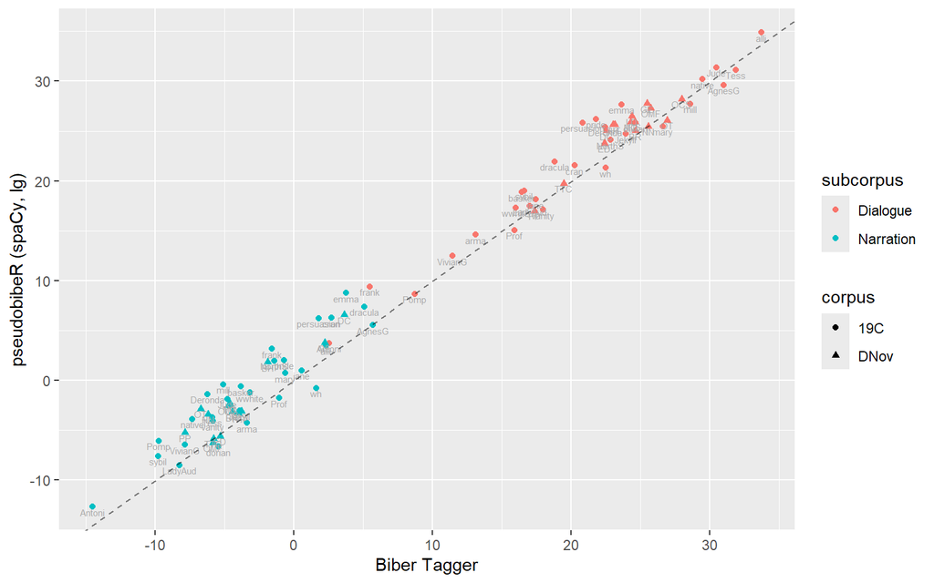

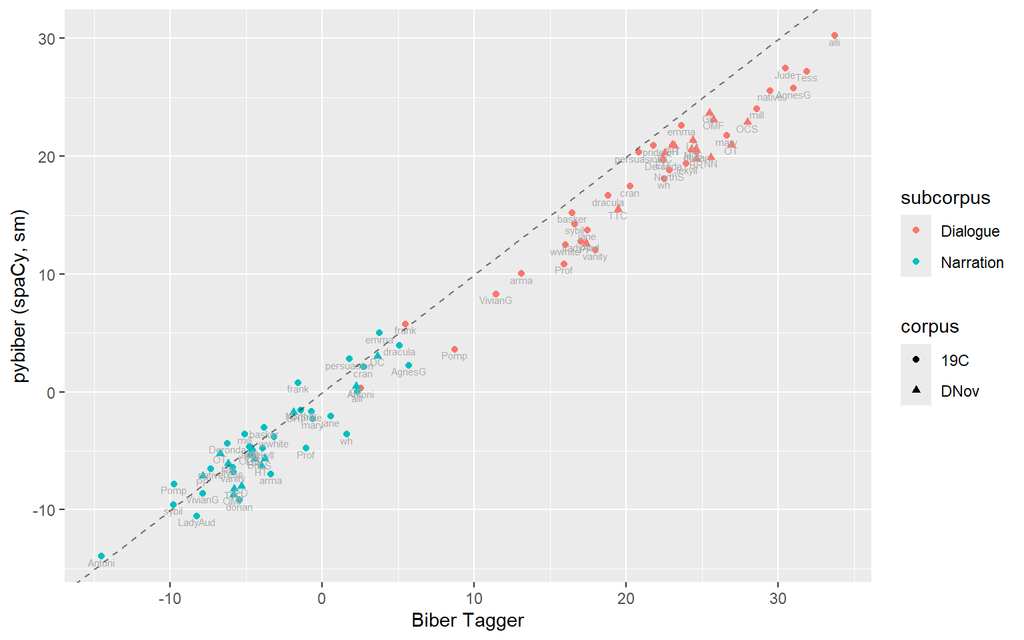

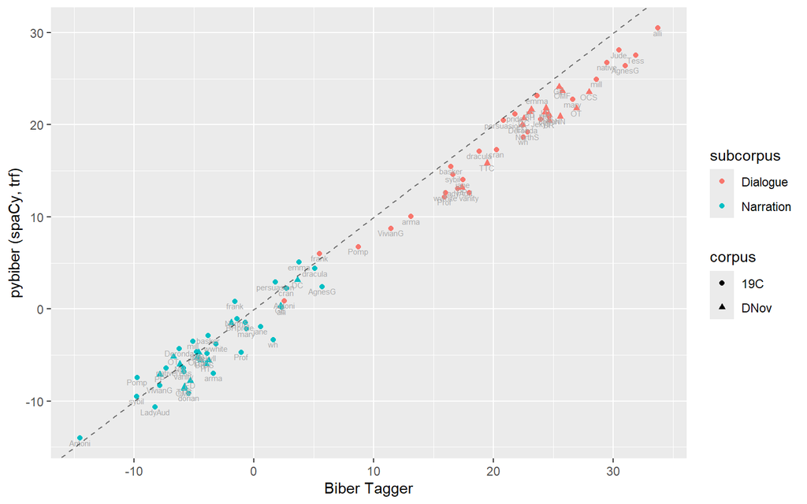

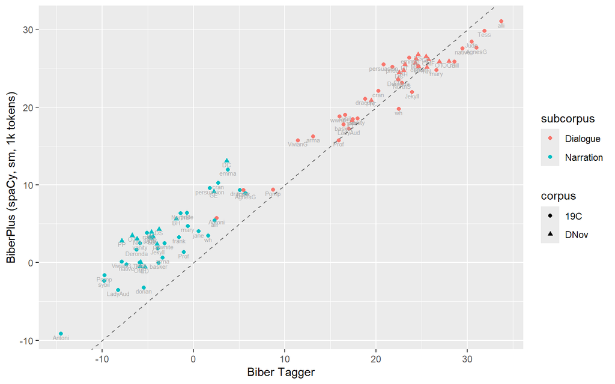

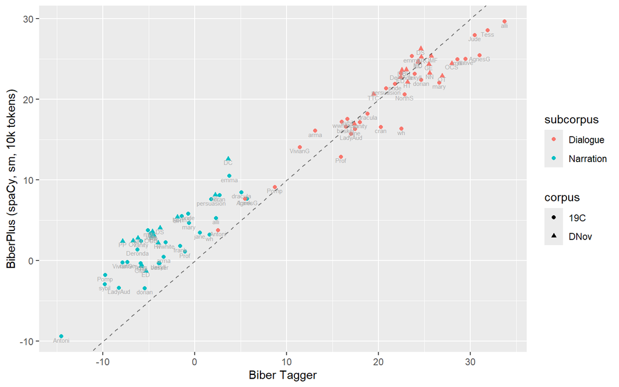

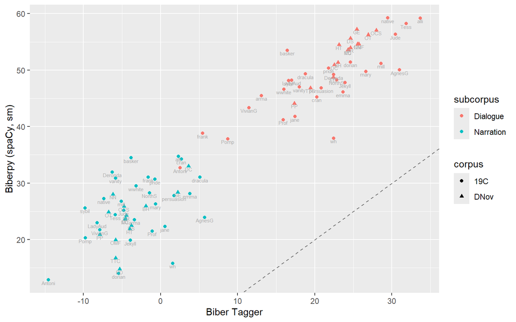

```r
biber_comparison_1v1 <- biber_comparison |>
  pivot_wider(names_from = method, values_from = Dimension1)

plot_1v1 <- function(method) {
  biber_comparison_1v1 |>
    ggplot(aes(x = `Biber Tagger`, y = !!as.name(method), colour = subcorpus, shape = corpus, label = doc_id)) +
    geom_point() +
    geom_text(size = 2, vjust = 1.2, colour = "darkgrey") +
    geom_abline(alpha = .5, linetype = 2)
}

systems <- levels(biber_comparison$method)
systems <- systems[systems != "Biber Tagger"]

for (s in systems) {
  print(plot_1v1(s))
  Sys.sleep(.5)
}
```

## Feature-level comparisons

To find out where the differences between individual systems/language models are coming from, we can look at the features underlying the register dimensions.

```r
mat_texts <- nini_zscores |>
  select(doc_id:subcorpus, `Linguistic feature`, feature_pseudobiber, mean, value, zscore) |>
  arrange(doc_id, corpus, subcorpus, feature_pseudobiber) |>
  mutate(system = "MAT: Stanford tagger", .before = "doc_id")

pseudobiber_texts_stanza <- pseudobiber_stanza_zscores |>
  select(doc_id:subcorpus, `Linguistic feature`, feature_pseudobiber, mean, value, zscore) |>
  arrange(doc_id, corpus, subcorpus, feature_pseudobiber) |>
  mutate(system = "pseudobibeR: Stanza", .before = "doc_id")

pseudobiber_texts_spacy_sm <- pseudobiber_spacy_sm_zscores |>
  select(doc_id:subcorpus, `Linguistic feature`, feature_pseudobiber, mean, value, zscore) |>
  arrange(doc_id, corpus, subcorpus, feature_pseudobiber) |>
  mutate(system = "pseudobibeR: spaCy (sm)", .before = "doc_id")

pybiber_texts_spacy_sm <- pybiber_spacy_sm_zscores |>
  select(doc_id:subcorpus, `Linguistic feature`, feature_pseudobiber, mean, value, zscore) |>
  arrange(doc_id, corpus, subcorpus, feature_pseudobiber) |>
  mutate(system = "pybiber: spaCy (sm)", .before = "doc_id")

biberplus_texts <- biberplus_zscores |>
  select(doc_id:subcorpus, `Linguistic feature`, feature_pseudobiber, mean, value, zscore) |>
  arrange(doc_id, corpus, subcorpus, feature_pseudobiber) |>
  mutate(system = "BiberPlus: spaCy (sm)", .before = "doc_id")

biberpy_texts <- biberpy_zscores |>
  select(doc_id:subcorpus, `Linguistic feature`, feature_pseudobiber, mean, value, zscore) |>
  arrange(doc_id, corpus, subcorpus, feature_pseudobiber) |>
  mutate(system = "Biberpy: spaCy (sm)", .before = "doc_id")

comparison <- bind_rows(mat_texts,
                        pseudobiber_texts_stanza,
                        pseudobiber_texts_spacy_sm,
                        pybiber_texts_spacy_sm,
                        biberplus_texts,
                        biberpy_texts) |>
  inner_join(biber_dims, by = "Linguistic feature") |>
  arrange(doc_id, corpus, subcorpus, feature_pseudobiber, system) |>
  mutate(system = factor(system,
                         levels = c("MAT: Stanford tagger", "pseudobibeR: Stanza", "pseudobibeR: spaCy (sm)", "pybiber: spaCy (sm)", "BiberPlus: spaCy (sm)", "Biberpy: spaCy (sm)")))

# comparison |> write_csv("comparison_mat_pseudobiber_pybiber_biberplus_biberpy.csv")
```

### Dimension 1

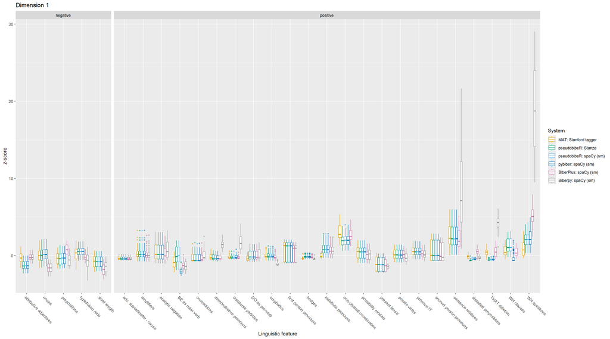

```r
comparison |>
  filter(dim1 != 0) |>
  mutate(contribution = ifelse(dim1 > 0, "positive", "negative")) |>
  ggplot(aes(x = `Linguistic feature`, y = zscore, colour = system)) +
  geom_boxplot(outlier.size = 1, outlier.alpha = .5) +
  theme(axis.text.x = element_text(angle = -45, hjust = 0), axis.title.y = element_markdown()) +
  facet_grid(cols = vars(contribution), scales = "free_x", space = "free") +
  scale_colour_oi(order = c(1, 3, 2, 5, 7, 8, 4, 6, 9)) +
  labs(y = "<i>z</i>-score", colour = "System", title = "Dimension 1")
```

We’ll use an upper limit for the y-axis to see things a little more clearly.

Features that would be removed by the filter:

- 13 (WH questions) is suspiciously high in Biberpy
- 23 (WH clauses) is lower for pybiber than for all others; the count is very often 0 for individual documents, as pybiber subtracts the counts of features 31 and 32
- 34 (sentence relatives) is practically identical for all systems except Biberpy (much higher)
- 47 (hedges) is slightly lower for MAT and Biberpy

Other observations:

- pseudobibeR, whether with spaCy or Stanza, and pybiber agree on attributive adjectives, as do MAT, BiberPlus and Biberpy – at a significantly higher level
- BiberPlus and Biberpy also agree on nouns, but all other systems count more; something similar can be observed for word length and type-token ratio (which shouldn’t be all that controversial)
- BiberPlus counts significantly more prepositions than the other systems
- Biberpy is the lone outlier for demonstrative pronouns, discourse particles, emphatics and sentence relatives; it also has very high values for THAT deletions
- MAT and BiberPlus count more non-phrasal coordinations
- pybiber changed its computation of BE as main verb (with an option to revert it to pseudobibeR’s behaviour); it now counts only counts it if a form of *to be* is the root of the sentence (whereas Biber’s original rule is more lax); this results in substantially lower counts

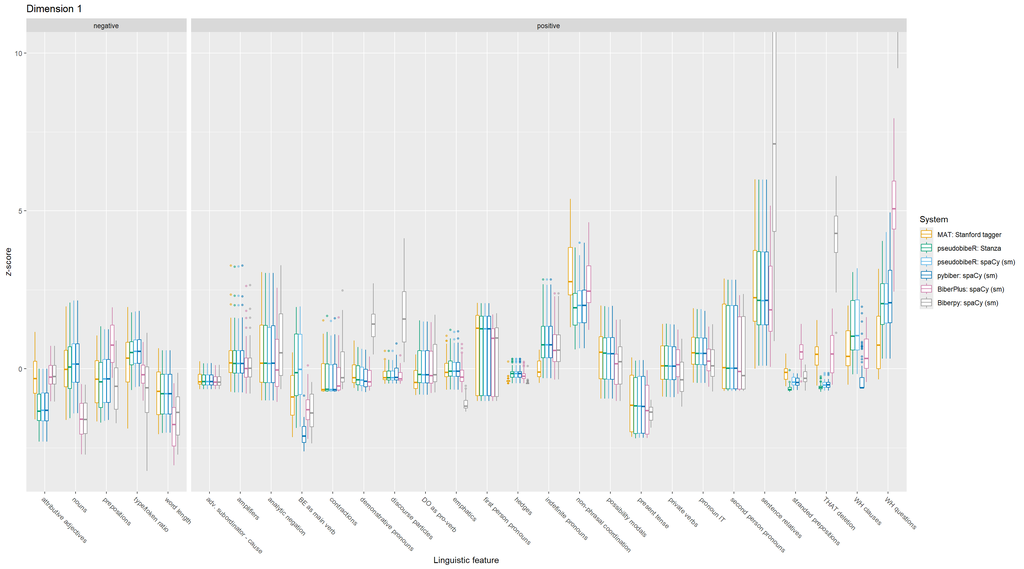

```r
dim1_comp <- comparison |>
  filter(dim1 != 0) |>
  mutate(contribution = ifelse(dim1 > 0, "positive", "negative")) |>
  ggplot(aes(x = `Linguistic feature`, y = zscore, colour = system)) +
  geom_boxplot(outlier.size = 1, outlier.alpha = .5) + # linewidth = .4, outlier.size = 1
  theme(axis.text.x = element_text(angle = -45, hjust = 0), axis.title.y = element_markdown()) +
  facet_grid(cols = vars(contribution), scales = "free_x", space = "free") +
  scale_colour_oi(order = c(1, 3, 2, 5, 7, 8, 4, 6, 9)) +
  labs(y = "<i>z</i>-score", colour = "System", title = "Dimension 1") +
  coord_cartesian(ylim=c(NA, 10))
dim1_comp
```

Only keeping features with a mean above 1 in Biber (1988) leaves us with 24 out of 28 features:

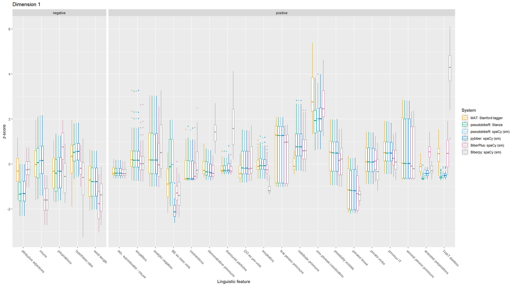

```r
comparison |>
  filter(dim1 != 0,
         mean > 1) |>
  mutate(contribution = ifelse(dim1 > 0, "positive", "negative")) |>
  ggplot(aes(x = `Linguistic feature`, y = zscore, colour = system)) +
  geom_boxplot(outlier.size = 1, outlier.alpha = .5) +
  theme(axis.text.x = element_text(angle = -45, hjust = 0), axis.title.y = element_markdown()) +
  facet_grid(cols = vars(contribution), scales = "free_x", space = "free") +
  scale_colour_oi(order = c(1, 3, 2, 5, 7, 8, 4, 6, 9)) +
  labs(y = "<i>z</i>-score", colour = "System", title = "Dimension 1")
```

### Dimension 2

BiberPlus has slightly lower values for all features than MAT, pseudobibeR and pybiber. Biberpy is missing two features, and counts for past tense and synthetic negatives are even lower than those from BiberPlus.

Without filtering:

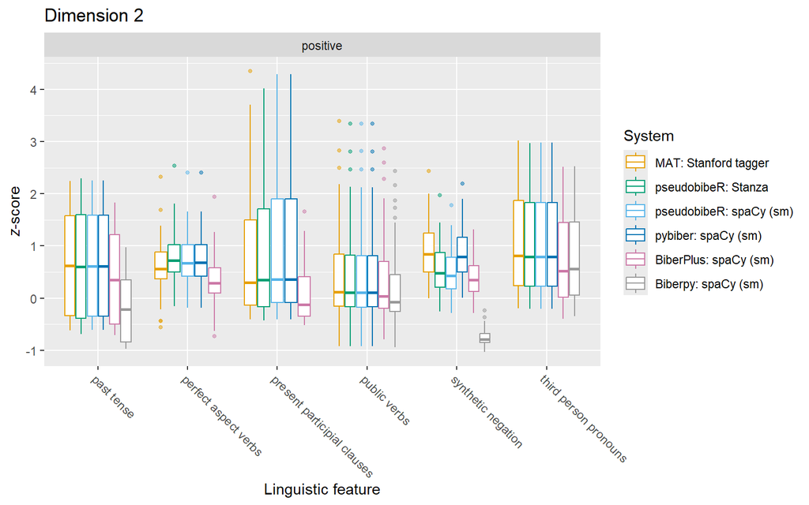

```r
dim2_comp <- comparison |>
  filter(dim2 != 0) |>
  mutate(contribution = ifelse(dim2 > 0, "positive", "negative")) |>
  ggplot(aes(x = `Linguistic feature`, y = zscore, colour = system)) +
  geom_boxplot(outlier.size = 1, outlier.alpha = .5) + # linewidth = .4, outlier.size = 1
  theme(axis.text.x = element_text(angle = -45, hjust = 0), axis.title.y = element_markdown()) +
  facet_grid(cols = vars(contribution), scales = "free_x", space = "free") +
  scale_colour_oi(order = c(1, 3, 2, 5, 7, 8, 4, 6, 9)) +
  labs(y = "<i>z</i>-score", colour = "System", title = "Dimension 2")
dim2_comp
```

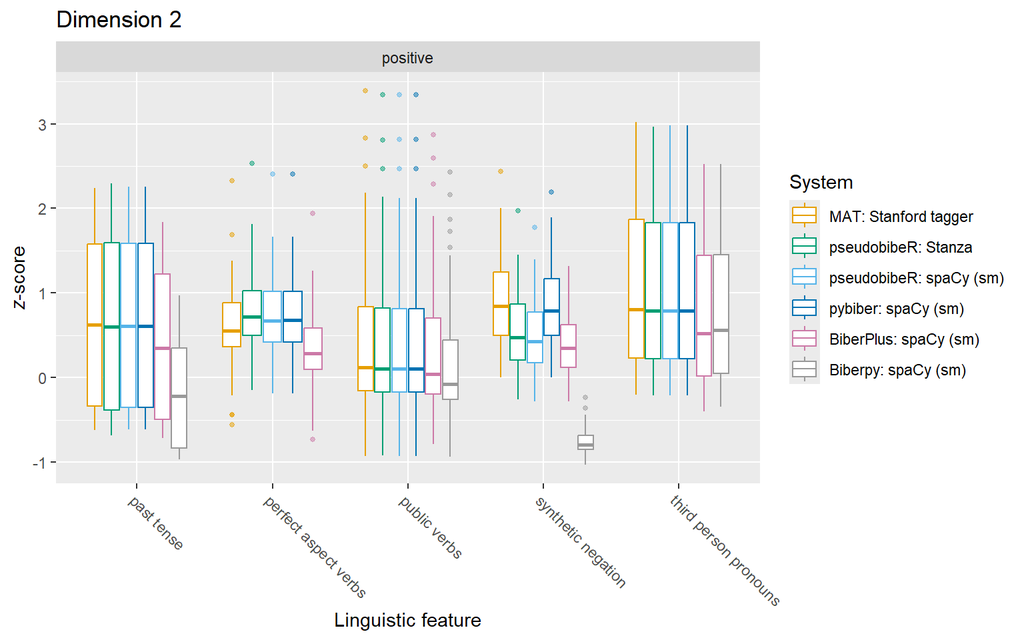

```r
comparison |>
  filter(dim2 != 0,
         mean > 1) |>
  mutate(contribution = ifelse(dim2 > 0, "positive", "negative")) |>
  ggplot(aes(x = `Linguistic feature`, y = zscore, colour = system)) +
  geom_boxplot(outlier.size = 1, outlier.alpha = .5) +
  theme(axis.text.x = element_text(angle = -45, hjust = 0), axis.title.y = element_markdown()) +
  facet_grid(cols = vars(contribution), scales = "free_x", space = "free") +
  scale_colour_oi(order = c(1, 3, 2, 5, 7, 8, 4, 6, 9)) +
  labs(y = "<i>z</i>-score", colour = "System", title = "Dimension 2")
```

### Dimension 3

Most obvious differences:

- much lower count of adverbs for MAT (and Biberpy, to a lesser extent) → much higher dim. 3
- slightly higher count of time adverbials for MAT → lower dim. 3
- lower count of WH relatives in subject position for MAT → lower dim. 3
- higher count of WH relatives in object position for BiberPlus (somewhat offset by slightly lower counts for WH relatives in subject position and phrasal coordinations, but a slightly lower adverb count also adds to the dim. 3 scores)

Without filtering:

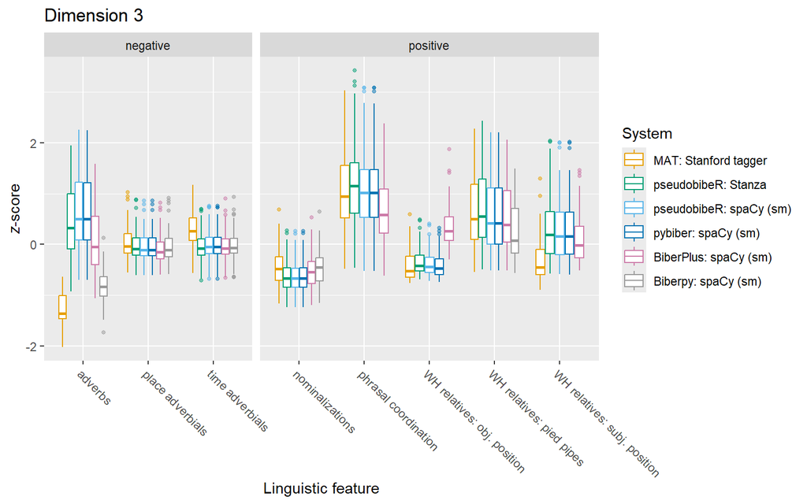

```r
dim3_comp <- comparison |>
  filter(dim3 != 0) |>
  mutate(contribution = ifelse(dim3 > 0, "positive", "negative")) |>
  ggplot(aes(x = `Linguistic feature`, y = zscore, colour = system)) +
  geom_boxplot(outlier.size = 1, outlier.alpha = .5) + # linewidth = .4, outlier.size = 1
  theme(axis.text.x = element_text(angle = -45, hjust = 0), axis.title.y = element_markdown()) +
  facet_grid(cols = vars(contribution), scales = "free_x", space = "free") +
  scale_colour_oi(order = c(1, 3, 2, 5, 7, 8, 4, 6, 9)) +
  labs(y = "<i>z</i>-score", colour = "System", title = "Dimension 3")
dim3_comp
```

With filtering, 7 out of 8 features are used: 33 (WH relatives: pied pipes) not included – similar for all taggers (slightly lower for Biberpy)

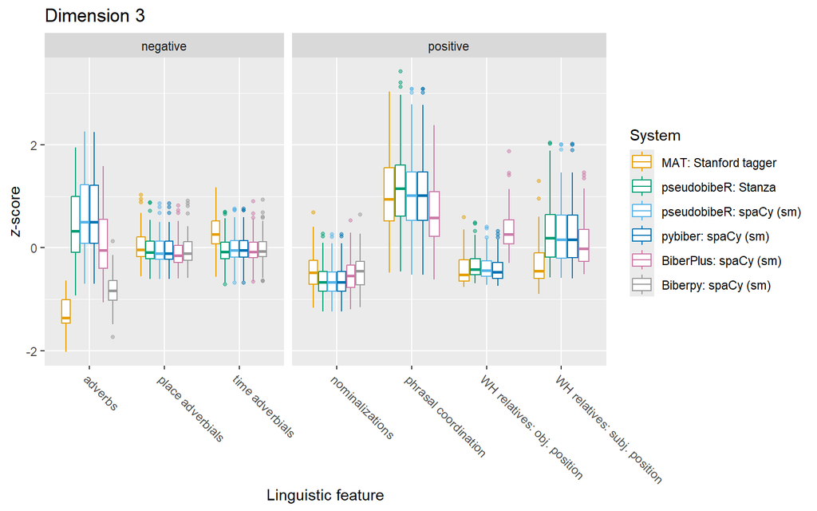

```r
comparison |>
  filter(dim3 != 0,
         mean > 1) |> #
  mutate(contribution = ifelse(dim3 > 0, "positive", "negative")) |>
  ggplot(aes(x = `Linguistic feature`, y = zscore, colour = system)) +
  geom_boxplot(outlier.size = 1, outlier.alpha = .5) +
  theme(axis.text.x = element_text(angle = -45, hjust = 0), axis.title.y = element_markdown()) +
  facet_grid(cols = vars(contribution), scales = "free_x", space = "free") +
  scale_colour_oi(order = c(1, 3, 2, 5, 7, 8, 4, 6, 9)) +
  labs(y = "<i>z</i>-score", colour = "System", title = "Dimension 3")
```

### Dimension 4

Since all feature means for dimension 4 in the original study are above 1, all features are included with or without filtering. Differences between MAT, pseudobibeR and pybiber are marginal – MAT only counts a few more split auxiliaries. BiberPlus, however, counts a lot more split auxiliaries which would result in much higher dimension 4 values if not for slightly lower counts for four of the other features.

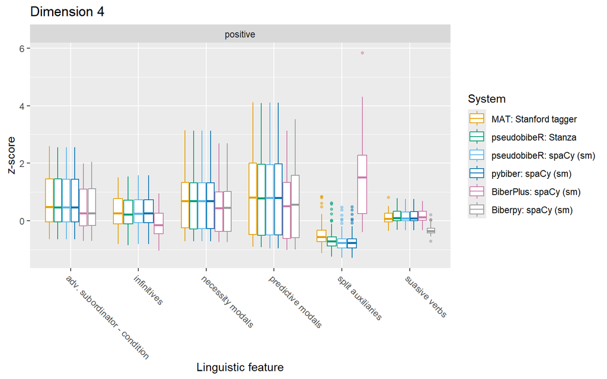

```r
dim4_comp <- comparison |>
  filter(dim4 != 0) |> # uses 6/6 features (filter makes no difference)
  mutate(contribution = ifelse(dim4 > 0, "positive", "negative")) |>
  ggplot(aes(x = `Linguistic feature`, y = zscore, colour = system)) +
  geom_boxplot(outlier.size = 1, outlier.alpha = .5) + # linewidth = .4, outlier.size = 1
  theme(axis.text.x = element_text(angle = -45, hjust = 0), axis.title.y = element_markdown()) +
  facet_grid(cols = vars(contribution), scales = "free_x", space = "free") +
  scale_colour_oi(order = c(1, 3, 2, 5, 7, 8, 4, 6, 9)) +
  labs(y = "<i>z</i>-score", colour = "System", title = "Dimension 4")
dim4_comp
```